# Cook County Final

Michael Kuhn

April 11, 2024

```r
knitr::opts_chunk$set(warning = FALSE, message = FALSE)
library(tidyverse)
library(RSQLite)
library(skimr)
library(cmfproperty)
library(tidymodels)
library(corrr)
library(DT)
library(stargazer)
library(ranger)

#devtools::install_github("cmf-uchicago/cmfproperty")

options(DT.options = list(dom = 't',
                          scrollX = TRUE,
                          scrollCollapse = TRUE
                          ))
```

```r
# create db connection
con <- DBI::dbConnect(RSQLite::SQLite(), "cook.sqlite")
```

# Part 1

Updated to explore Proviso Township (31).

## Section A

Conduct an exploratory data analysis. Offer an overview of relevant trends in the data and data quality issues. Contextualize your analysis with past issues and recent improvements by the Assessor.

### Sales

```r
proviso_sales <-
  dplyr::tbl(con, 'sales') %>%
    filter(township_code == 31) %>%
    select(!township_code) %>% # select out now, so it isn't annoying later
    collect()
```

#### Skim Results

There are three years in the dataset: 2021, 2022, and 2023. The sales price range from $100 to $1,900,000.

`sales` is mostly missing `sale_type`, other variables with missing values are more than 0.89 complete.

```r
proviso_sales %>% skim()
```

Data summary

| Name | Piped data |
| --- | --- |
| Number of rows | 4154 |
| Number of columns | 18 |
| _______________________ |  |
| Column type frequency: |  |
| character | 9 |
| numeric | 9 |
| ________________________ |  |
| Group variables | None |

**Variable type: character**

| skim_variable | n_missing | complete_rate | min | max | empty | n_unique | whitespace |
| --- | --- | --- | --- | --- | --- | --- | --- |
| pin | 0 | 1.00 | 14 | 14 | 0 | 3767 | 0 |
| nbhd_code | 0 | 1.00 | 5 | 5 | 0 | 32 | 0 |
| class | 0 | 1.00 | 3 | 3 | 0 | 10 | 0 |
| doc_no | 0 | 1.00 | 10 | 10 | 0 | 4028 | 0 |
| deed_type | 91 | 0.98 | 5 | 13 | 0 | 3 | 0 |
| mydec_deed_type | 405 | 0.90 | 5 | 21 | 0 | 12 | 0 |
| seller_name | 157 | 0.96 | 3 | 453 | 0 | 3696 | 0 |
| buyer_name | 58 | 0.99 | 3 | 304 | 0 | 3892 | 0 |
| sale_type | 4154 | 0.00 | NA | NA | 0 | 0 | 0 |

**Variable type: numeric**

| skim_variable | n_missing | complete_rate | mean | sd | p0 | p25 | p50 | p75 | p100 | hist |
| --- | --- | --- | --- | --- | --- | --- | --- | --- | --- | --- |
| year | 0 | 1.00 | 2.021860e+03 | 0.77 | 2021 | 2021 | 2022 | 2022 | 2023 | ▇▁▇▁▅ |
| sale_date | 0 | 1.00 | 1.651088e+09 | 24106892.27 | 1609718400 | 1630281600 | 1651104000 | 1670976000 | 1695772800 | ▆▇▇▆▆ |
| is_mydec_date | 0 | 1.00 | 1.000000e+00 | 0.00 | 1 | 1 | 1 | 1 | 1 | ▁▁▇▁▁ |
| sale_price | 0 | 1.00 | 2.905538e+05 | 141192.19 | 100 | 218000 | 273000 | 335000 | 1900000 | ▇▂▁▁▁ |
| is_multisale | 0 | 1.00 | 1.800000e-01 | 0.38 | 0 | 0 | 0 | 0 | 1 | ▇▁▁▁▂ |
| num_parcels_sale | 383 | 0.91 | 1.100000e+00 | 0.32 | 1 | 1 | 1 | 1 | 4 | ▇▁▁▁▁ |
| sale_filter_same_sale_within_365 | 0 | 1.00 | 0.000000e+00 | 0.04 | 0 | 0 | 0 | 0 | 1 | ▇▁▁▁▁ |
| sale_filter_less_than_10k | 0 | 1.00 | 0.000000e+00 | 0.04 | 0 | 0 | 0 | 0 | 1 | ▇▁▁▁▁ |
| sale_filter_deed_type | 0 | 1.00 | 2.000000e-02 | 0.15 | 0 | 0 | 0 | 0 | 1 | ▇▁▁▁▁ |

#### Glimpse of Variables

```r
proviso_sales %>% glimpse()
```

```
## Rows: 4,154
## Columns: 18
## $ pin                              <chr> "15291080300000", "15221120280000", "…
## $ year                             <dbl> 2021, 2021, 2021, 2021, 2021, 2021, 2…
## $ nbhd_code                        <chr> "31104", "31030", "31174", "31020", "…
## $ class                            <chr> "234", "203", "278", "203", "206", "2…
## $ sale_date                        <dbl> 1612483200, 1636329600, 1619395200, 1…
## $ is_mydec_date                    <int> 1, 1, 1, 1, 1, 1, 1, 1, 1, 1, 1, 1, 1…
## $ sale_price                       <dbl> 350000, 275000, 369900, 210000, 18000…
## $ doc_no                           <chr> "2111725050", "2200740033", "21158081…
## $ deed_type                        <chr> "Warranty Deed", "Trustee Deed", "War…
## $ mydec_deed_type                  <chr> "Warranty Deed", "Trustee Deed", "War…
## $ seller_name                      <chr> "PRAIRIE CAVE, LLC", "DARRYL H. ARMST…
## $ is_multisale                     <int> 1, 0, 0, 0, 1, 0, 0, 0, 0, 0, 0, 0, 1…
## $ num_parcels_sale                 <dbl> NA, 1, 1, 1, 2, 1, 1, 1, 1, 1, 1, 1, …
## $ buyer_name                       <chr> "SYLVESTER  RANDOLPH III", "PATRICK  …
## $ sale_filter_same_sale_within_365 <int> 0, 0, 0, 0, 0, 0, 0, 0, 0, 0, 0, 0, 0…
## $ sale_filter_less_than_10k        <int> 0, 0, 0, 0, 0, 0, 0, 0, 0, 0, 0, 0, 0…
## $ sale_filter_deed_type            <int> 0, 0, 0, 0, 0, 0, 0, 0, 0, 0, 0, 0, 0…
## $ sale_type                        <chr> NA, NA, NA, NA, NA, NA, NA, NA, NA, N…
```

Viewing seasonal distribution

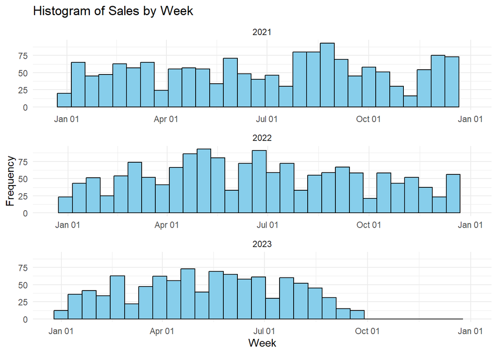

```r
week_limit <-
  function(x) {
    c(floor_date(min(x), "week"),
      ceiling_date(max(x) - weeks(1), "year"))
  }

proviso_sales %>%
  mutate(sale_date = as_datetime(sale_date),
         sale_date = as_date(sale_date), # I feel like this is suboptimal
         sale_week = floor_date(sale_date, "week"),
         sale_week = as.Date(sale_week)
         ) %>%
  ggplot(aes(x = sale_week)) +
  geom_histogram(fill = "skyblue", color = "black") +
  facet_wrap(~ year, ncol = 1, scales = "free_x") +
  scale_x_date(date_labels = "%b %d",
               limits = week_limit) + # close enough for now
  labs(
    title = "Histogram of Sales by Week",
    x = "Week",
    y = "Frequency"
  ) +
  theme_minimal()
```

I thought this would be better but I don’t think it is.

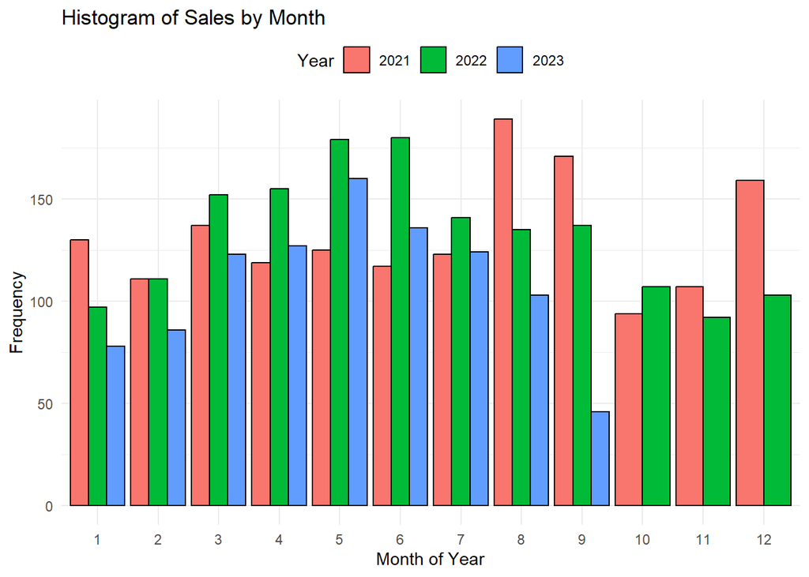

```r
proviso_sales %>%
  mutate(sale_date = as.Date(as_datetime(sale_date))) %>%
  mutate(sale_month_of_year = month(sale_date)) %>%
  count(sale_month_of_year, year) %>%
  ggplot(aes(x = as.factor(sale_month_of_year), y = n, fill = as.factor(year))) +
  geom_bar(stat = "identity", position = "dodge", color = "black") +
  labs(
    title = "Histogram of Sales by Month",
    x = "Month of Year",
    y = "Frequency",
    fill = "Year"
  ) +
  theme_minimal() +
  theme(legend.position = "top")  # Optional: move legend to the top
```

#### Exploring Trends

```r
# Explore trends
proviso_sales %>%
  group_by(year) %>%
  summarize(n(),
            mean(sale_price),
            median(sale_price)) %>%
  DT::datatable()
```

|  | year | n() | mean(sale_price) | median(sale_price) |
| --- | --- | --- | --- | --- |
| 1 | 2021 | 1582 | 280509.1251580278 | 262750 |
| 2 | 2022 | 1589 | 294065.1302706104 | 275000 |
| 3 | 2023 | 983 | 301043.4598168871 | 284000 |

##### Viewing exceptions noted in the documentation

The dataset documentation notes that each row is a sale, and some properties may be sold multiple times in one year. It also notes that previous versions filtered out sales less than 10k and by deed type. Through summarizing, we see that there are not many instances where these filters are relevant.

```r
# view exceptions noted in documentation counts
proviso_sales %>%
  summarize(n(),
            sum(sale_filter_same_sale_within_365),
            sum(sale_filter_less_than_10k),
            sum(sale_filter_deed_type)) %>%
  DT::datatable()
```

|  | n() | sum(sale_filter_same_sale_within_365) | sum(sale_filter_less_than_10k) | sum(sale_filter_deed_type) |
| --- | --- | --- | --- | --- |
| 1 | 4154 | 7 | 6 | 91 |

### Assessments

```r
proviso_assess <-
  dplyr::tbl(con, 'assessments') %>%
    filter(township_code == 31) %>%
    select(!c(township_code, township_name)) %>%
    mutate(class = as.character(as.integer(class))) %>% # not sure why class is double...
    collect()
```

#### Skim Results

```r
proviso_assess %>% skim()
```

Data summary

| Name | Piped data |
| --- | --- |
| Number of rows | 107604 |
| Number of columns | 12 |
| _______________________ |  |
| Column type frequency: |  |
| character | 2 |
| numeric | 10 |
| ________________________ |  |
| Group variables | None |

**Variable type: character**

| skim_variable | n_missing | complete_rate | min | max | empty | n_unique | whitespace |
| --- | --- | --- | --- | --- | --- | --- | --- |
| pin | 0 | 1 | 14 | 14 | 0 | 35917 | 0 |
| class | 0 | 1 | 3 | 3 | 0 | 10 | 0 |

**Variable type: numeric**

| skim_variable | n_missing | complete_rate | mean | sd | p0 | p25 | p50 | p75 | p100 | hist |
| --- | --- | --- | --- | --- | --- | --- | --- | --- | --- | --- |
| tax_year | 0 | 1.00 | 2022.00 | 0.82 | 2021 | 2021 | 2022.0 | 2023.00 | 2023 | ▇▁▇▁▇ |
| mailed_bldg | 0 | 1.00 | 18794.54 | 8973.15 | 436 | 13932 | 16953.0 | 21280.25 | 138471 | ▇▁▁▁▁ |
| mailed_land | 0 | 1.00 | 3653.09 | 1508.17 | 0 | 2680 | 3438.0 | 4318.00 | 88484 | ▇▁▁▁▁ |
| mailed_tot | 0 | 1.00 | 22447.63 | 9884.35 | 1787 | 16876 | 20616.5 | 25001.00 | 157652 | ▇▁▁▁▁ |
| certified_bldg | 0 | 1.00 | 18731.73 | 8876.05 | 436 | 13911 | 16923.0 | 21225.00 | 138471 | ▇▁▁▁▁ |
| certified_land | 0 | 1.00 | 3653.09 | 1508.17 | 0 | 2680 | 3438.0 | 4318.00 | 88484 | ▇▁▁▁▁ |
| certified_tot | 0 | 1.00 | 22384.82 | 9790.23 | 1787 | 16845 | 20566.5 | 25001.00 | 157652 | ▇▁▁▁▁ |
| board_bldg | 35861 | 0.67 | 16920.77 | 7690.60 | 436 | 12952 | 15311.0 | 18824.50 | 137466 | ▇▁▁▁▁ |
| board_land | 35861 | 0.67 | 3411.21 | 1396.09 | 0 | 2546 | 3093.0 | 4020.00 | 77555 | ▇▁▁▁▁ |
| board_tot | 35861 | 0.67 | 20331.98 | 8520.09 | 1787 | 15783 | 18367.0 | 22798.50 | 157652 | ▇▁▁▁▁ |

#### Glimpse of Variables

```r
proviso_assess %>% glimpse()
```

```
## Rows: 107,604
## Columns: 12
## $ pin            <chr> "15021060110000", "15021070340000", "15023170150000", "…
## $ tax_year       <dbl> 2021, 2021, 2021, 2021, 2021, 2021, 2021, 2021, 2021, 2…
## $ class          <chr> "234", "205", "205", "205", "205", "205", "206", "206",…
## $ mailed_bldg    <dbl> 10040, 18815, 13437, 12949, 18145, 19749, 20592, 26668,…
## $ mailed_land    <dbl> 3900, 3912, 1595, 3310, 5469, 3900, 3900, 3230, 3300, 4…
## $ mailed_tot     <dbl> 13940, 22727, 15032, 16259, 23614, 23649, 24492, 29898,…
## $ certified_bldg <dbl> 10040, 18815, 13437, 12949, 18145, 19749, 20592, 26668,…
## $ certified_land <dbl> 3900, 3912, 1595, 3310, 5469, 3900, 3900, 3230, 3300, 4…
## $ certified_tot  <dbl> 13940, 22727, 15032, 16259, 23614, 23649, 24492, 29898,…
## $ board_bldg     <dbl> 10040, 18815, 13437, 11902, 18145, 19749, 20592, 26668,…
## $ board_land     <dbl> 3900, 3912, 1595, 3310, 5469, 3900, 3900, 3230, 3300, 4…
## $ board_tot      <dbl> 13940, 22727, 15032, 15212, 23614, 23649, 24492, 29898,…
```

#### Investigate Missing Variables

```r
# investigate missing variables
proviso_assess %>%
  group_by(tax_year) %>%
  summarize(bldg_na = sum(is.na(board_bldg)),
            land_na = sum(is.na(board_bldg)),
            tot_na = sum(is.na(board_tot))) %>%
  DT::datatable()
```

|  | tax_year | bldg_na | land_na | tot_na |
| --- | --- | --- | --- | --- |
| 1 | 2021 | 0 | 0 | 0 |
| 2 | 2022 | 0 | 0 | 0 |
| 3 | 2023 | 35861 | 35861 | 35861 |

#### Exploring Trends

```r
# trends
proviso_assess %>%
  group_by(tax_year) %>%
  summarize(n(),
            mean(certified_tot),
            median(certified_tot)) %>%
  DT::datatable()
```

|  | tax_year | n() | mean(certified_tot) | median(certified_tot) |
| --- | --- | --- | --- | --- |
| 1 | 2021 | 35872 | 20495.45506244425 | 18460.5 |
| 2 | 2022 | 35871 | 20364.24292604053 | 18379 |
| 3 | 2023 | 35861 | 26295.9121887287 | 24000 |

### Characteristics

```r
proviso_char <-
  dplyr::tbl(con, 'characteristics') %>%
    filter(township_code == 31) %>%
    select(!township_code) %>%
    collect()
```

#### Skim Results

`characteristics` is mostly missing `tieback_key_pin`, other variables with missing values are more than 0.885 complete. However, it only has data for 2023.

The documentation notes that the Assessor recently changed how Home Improvement Exceptions (HIE) work, in order to encourage property improvements. Records prior to 2021 do not include HIE characteristics.

Each row is an improvement, but some improvements count as a renovation or that variable is capturing improvements from prior years. Some properties have multiple improvements.

```r
proviso_char %>% skim()
```

Data summary

| Name | Piped data |
| --- | --- |
| Number of rows | 36003 |
| Number of columns | 43 |
| _______________________ |  |
| Column type frequency: |  |
| character | 25 |
| numeric | 18 |
| ________________________ |  |
| Group variables | None |

**Variable type: character**

| skim_variable | n_missing | complete_rate | min | max | empty | n_unique | whitespace |
| --- | --- | --- | --- | --- | --- | --- | --- |
| pin | 0 | 1.00 | 14 | 14 | 0 | 35923 | 0 |
| class | 0 | 1.00 | 3 | 3 | 0 | 10 | 0 |
| cdu | 53 | 1.00 | 2 | 2 | 0 | 5 | 0 |
| char_type_resd | 0 | 1.00 | 7 | 11 | 0 | 5 | 0 |
| char_cnst_qlty | 0 | 1.00 | 4 | 7 | 0 | 3 | 0 |
| char_apts | 11 | 1.00 | 3 | 5 | 0 | 4 | 0 |
| char_attic_fnsh | 13 | 1.00 | 4 | 11 | 0 | 3 | 0 |
| char_gar1_att | 12 | 1.00 | 2 | 3 | 0 | 2 | 0 |
| char_gar1_area | 12 | 1.00 | 2 | 3 | 0 | 2 | 0 |
| char_gar1_size | 11 | 1.00 | 6 | 8 | 0 | 8 | 0 |
| char_gar1_cnst | 2819 | 0.92 | 5 | 15 | 0 | 4 | 0 |
| char_attic_type | 0 | 1.00 | 4 | 7 | 0 | 3 | 0 |
| char_bsmt | 1 | 1.00 | 4 | 7 | 0 | 4 | 0 |
| char_ext_wall | 0 | 1.00 | 5 | 15 | 0 | 4 | 0 |
| char_heat | 0 | 1.00 | 4 | 16 | 0 | 4 | 0 |
| char_repair_cnd | 0 | 1.00 | 7 | 13 | 0 | 3 | 0 |
| char_bsmt_fin | 38 | 1.00 | 9 | 15 | 0 | 3 | 0 |
| char_roof_cnst | 0 | 1.00 | 4 | 17 | 0 | 6 | 0 |
| char_use | 1 | 1.00 | 12 | 13 | 0 | 2 | 0 |
| char_site | 0 | 1.00 | 19 | 21 | 0 | 3 | 0 |
| char_renovation | 7 | 1.00 | 2 | 3 | 0 | 2 | 0 |
| char_porch | 5 | 1.00 | 4 | 16 | 0 | 3 | 0 |
| char_air | 0 | 1.00 | 11 | 14 | 0 | 2 | 0 |
| char_tp_plan | 0 | 1.00 | 4 | 10 | 0 | 3 | 0 |
| tieback_key_pin | 33762 | 0.06 | 14 | 14 | 0 | 1106 | 0 |

**Variable type: numeric**

| skim_variable | n_missing | complete_rate | mean | sd | p0 | p25 | p50 | p75 | p100 | hist |
| --- | --- | --- | --- | --- | --- | --- | --- | --- | --- | --- |
| year | 0 | 1 | 2023.00 | 0.00 | 2023 | 2023 | 2023 | 2023 | 2023.00 | ▁▁▇▁▁ |
| card | 0 | 1 | 1.00 | 0.07 | 1 | 1 | 1 | 1 | 3.00 | ▇▁▁▁▁ |
| tieback_proration_rate | 0 | 1 | 0.97 | 0.13 | 0 | 1 | 1 | 1 | 1.00 | ▁▁▁▁▇ |
| card_proration_rate | 59 | 1 | 0.03 | 0.13 | 0 | 0 | 0 | 0 | 0.95 | ▇▁▁▁▁ |
| pin_is_multicard | 0 | 1 | 0.01 | 0.08 | 0 | 0 | 0 | 0 | 1.00 | ▇▁▁▁▁ |
| pin_num_cards | 0 | 1 | 1.01 | 0.08 | 1 | 1 | 1 | 1 | 3.00 | ▇▁▁▁▁ |
| pin_is_multiland | 11 | 1 | 0.00 | 0.01 | 0 | 0 | 0 | 0 | 1.00 | ▇▁▁▁▁ |
| pin_num_landlines | 11 | 1 | 1.00 | 0.01 | 1 | 1 | 1 | 1 | 2.00 | ▇▁▁▁▁ |
| char_yrblt | 0 | 1 | 1945.05 | 20.43 | 1814 | 1928 | 1952 | 1956 | 2023.00 | ▁▁▃▇▁ |
| char_bldg_sf | 0 | 1 | 1342.56 | 475.55 | 0 | 1017 | 1212 | 1550 | 5728.00 | ▆▇▁▁▁ |
| char_land_sf | 13 | 1 | 5994.96 | 2432.26 | 610 | 4600 | 6215 | 6700 | 221211.00 | ▇▁▁▁▁ |
| char_beds | 0 | 1 | 3.04 | 0.76 | 0 | 3 | 3 | 3 | 9.00 | ▁▇▂▁▁ |
| char_rooms | 0 | 1 | 5.86 | 1.27 | 0 | 5 | 6 | 7 | 15.00 | ▁▇▂▁▁ |
| char_fbath | 1 | 1 | 1.29 | 0.52 | 0 | 1 | 1 | 2 | 9.00 | ▇▃▁▁▁ |
| char_hbath | 33 | 1 | 0.36 | 0.50 | 0 | 0 | 0 | 1 | 5.00 | ▇▁▁▁▁ |
| char_frpl | 35 | 1 | 0.19 | 0.44 | 0 | 0 | 0 | 0 | 5.00 | ▇▁▁▁▁ |
| char_ncu | 40 | 1 | 0.00 | 0.00 | 0 | 0 | 0 | 0 | 0.00 | ▁▁▇▁▁ |
| recent_renovation | 0 | 1 | 0.00 | 0.07 | 0 | 0 | 0 | 0 | 1.00 | ▇▁▁▁▁ |

#### Glimpse Variables

```r
proviso_char %>% glimpse()
```

```
## Rows: 36,003
## Columns: 43
## $ pin                    <chr> "15021080020000", "15021080040000", "1502110015…
## $ year                   <dbl> 2023, 2023, 2023, 2023, 2023, 2023, 2023, 2023,…
## $ card                   <dbl> 1, 1, 1, 1, 1, 1, 1, 1, 1, 1, 1, 1, 1, 1, 1, 1,…
## $ class                  <chr> "205", "205", "205", "205", "205", "205", "205"…
## $ tieback_proration_rate <dbl> 1, 1, 1, 1, 1, 1, 1, 1, 1, 1, 1, 1, 1, 1, 1, 1,…
## $ card_proration_rate    <dbl> 0, 0, 0, 0, 0, 0, 0, 0, 0, 0, 0, 0, 0, 0, 0, 0,…
## $ cdu                    <chr> "AV", "AV", "GD", "AV", "AV", "AV", "AV", "AV",…
## $ pin_is_multicard       <int> 0, 0, 0, 0, 0, 0, 0, 0, 0, 0, 0, 0, 0, 0, 0, 0,…
## $ pin_num_cards          <dbl> 1, 1, 1, 1, 1, 1, 1, 1, 1, 1, 1, 1, 1, 1, 1, 1,…
## $ pin_is_multiland       <int> 0, 0, 0, 0, 0, 0, 0, 0, 0, 0, 0, 0, 0, 0, 0, 0,…
## $ pin_num_landlines      <dbl> 1, 1, 1, 1, 1, 1, 1, 1, 1, 1, 1, 1, 1, 1, 1, 1,…
## $ char_yrblt             <dbl> 1958, 1958, 1957, 1957, 1957, 1957, 1957, 1931,…
## $ char_bldg_sf           <dbl> 1862, 1918, 1918, 1918, 1918, 1918, 1827, 1648,…
```

[output cut: 30 more lines]

#### Investigate Missing Variables

```r
proviso_char %>%
  filter(!is.na(tieback_key_pin)) %>%
  DT::datatable()
```

|  | pin | year | card | class | tieback_proration_rate | card_proration_rate | cdu | pin_is_multicard | pin_num_cards | pin_is_multiland | pin_num_landlines | char_yrblt | char_bldg_sf | char_land_sf | char_beds | char_rooms | char_fbath | char_hbath | char_frpl | char_type_resd | char_cnst_qlty | char_apts | char_attic_fnsh | char_gar1_att | char_gar1_area | char_gar1_size | char_gar1_cnst | char_attic_type | char_bsmt | … |
| --- | --- | --- | --- | --- | --- | --- | --- | --- | --- | --- | --- | --- | --- | --- | --- | --- | --- | --- | --- | --- | --- | --- | --- | --- | --- | --- | --- | --- | --- | --- |
| 1 | 15034190090000 | 2023 | 1 | 204 | 0.2 | 0.2 | AV | 0 | 1 | 0 | 1 | 1958 | 2338 | 1050 | 4 | 6 | 2 | 1 | 1 | 1 Story | Average | None | None | Yes | No | 2 cars | Masonry | None | Slab | … |
| 2 | 15041060110000 | 2023 | 1 | 204 | 0.5 | 0.5 | AV | 0 | 1 | 0 | 1 | 1948 | 2095 | 3720 | 3 | 6 | 2 | 0 | 0 | 1 Story | Average | None | None | No | No | 2 cars | Frame | None | Slab | … |
| 3 | 15052080220000 | 2023 | 1 | 206 | 0.5 | 0.5 | AV | 0 | 1 | 0 | 1 | 1940 | 2493 | 3660 | 6 | 8 | 2 | 0 | 0 | 2 Story | Average | None | None | Yes | No | 1.5 cars | Frame | None | Slab | … |
| 4 | 15083280050000 | 2023 | 1 | 203 | 0.5 | 0.5 | AV | 0 | 1 | 0 | 1 | 1957 | 1116 | 3000 | 3 | 4 | 1 | 0 | 0 | 1 Story | Average | None | None | No | No | 2 cars | Frame | None | Full | … |
| 5 | 15033390160000 | 2023 | 1 | 203 | 0.5 | 0.5 | AV | 0 | 1 | 0 | 1 | 1955 | 1512 | 3300 | 3 | 7 | 1 | 1 | 1 | 1 Story | Average | None | None | Yes | No | 2.5 cars | Masonry | None | Full | … |
| 6 | 15023220050000 | 2023 | 1 | 203 | 0.5 | 0.5 | AV | 0 | 1 | 0 | 1 | 1956 | 1275 | 3900 | 3 | 6 | 1 | 0 | 0 | 1 Story | Average | None | None | No | No | 0 cars |  | None | Partial | … |
| 7 | 15031220290000 | 2023 | 1 | 203 | 0.5 | 0.5 | AV | 0 | 1 | 0 | 1 | 1949 | 1491 | 4125 | 4 | 6 | 2 | 0 | 0 | 1 Story | Average | None | None | No | No | 2 cars | Frame | Partial | Crawl | … |
| 8 | 15034420260000 | 2023 | 1 | 203 | 0.3 | 0.3 | AV | 0 | 1 | 0 | 1 | 1957 | 1561 | 2100 | 4 | 6 | 2 | 0 | 0 | 1 Story | Average | None | None | No | No | 1 cars | Frame | None | Slab | … |
| 9 | 15083180030000 | 2023 | 1 | 202 | 0.5 | 0.5 | AV | 0 | 1 | 0 | 1 | 1958 | 992 | 3810 | 3 | 4 | 1 | 0 | 0 | 1 Story | Average | None | None | No | No | 2.5 cars | Frame | Full | Full | … |
| 10 | 15091180360000 | 2023 | 1 | 203 | 0.2 | 0.2 | AV | 0 | 1 | 0 | 1 | 1956 | 1008 | 3750 | 3 | 5 | 1 | 0 | 0 | 1 Story | Average | None | None | No | No | 1.5 cars | Frame | None | Full | … |

[output cut: 2231 more lines]

#### Explore Trends

```r
# trends, only one year, so maybe year built is interesting
proviso_char %>%
  group_by(char_yrblt) %>%
  summarize(n(),
            pct_reno = mean(recent_renovation)) %>%
  arrange(desc(pct_reno)) %>%
  DT::datatable()
```

|  | char_yrblt | n() | pct_reno |
| --- | --- | --- | --- |
| 1 | 1836 | 1 | 1 |
| 2 | 1868 | 18 | 0.05555555555555555 |
| 3 | 1891 | 32 | 0.03125 |
| 4 | 1934 | 32 | 0.03125 |
| 5 | 1909 | 111 | 0.02702702702702703 |
| 6 | 1894 | 41 | 0.02439024390243903 |
| 7 | 1933 | 43 | 0.02325581395348837 |
| 8 | 1999 | 43 | 0.02325581395348837 |
| 9 | 1908 | 405 | 0.01481481481481482 |
| 10 | 1922 | 532 | 0.0131578947368421 |

[output cut: 151 more lines]

### Geospatial Universe

```r
proviso_geo <-
  dplyr::tbl(con, 'geospatial_universe') %>%
    filter(township_code == 31) %>%
    select(!township_code) %>%
    mutate(nbhd_code = as.character(as.integer(nbhd_code))) %>%
    collect()
```

#### Skim Results

`geospatial_universe` variables are all complete. This table also only has data for 2023. There is one record per PIN.

```r
proviso_geo %>% skim()
```

Data summary

| Name | Piped data |
| --- | --- |
| Number of rows | 35861 |
| Number of columns | 7 |
| _______________________ |  |
| Column type frequency: |  |
| character | 4 |
| numeric | 3 |
| ________________________ |  |
| Group variables | None |

**Variable type: character**

| skim_variable | n_missing | complete_rate | min | max | empty | n_unique | whitespace |
| --- | --- | --- | --- | --- | --- | --- | --- |
| pin | 0 | 1 | 14 | 14 | 0 | 35861 | 0 |
| class | 0 | 1 | 3 | 3 | 0 | 10 | 0 |
| triad_name | 0 | 1 | 5 | 5 | 0 | 1 | 0 |
| nbhd_code | 0 | 1 | 5 | 5 | 0 | 32 | 0 |

**Variable type: numeric**

| skim_variable | n_missing | complete_rate | mean | sd | p0 | p25 | p50 | p75 | p100 | hist |
| --- | --- | --- | --- | --- | --- | --- | --- | --- | --- | --- |
| year | 0 | 1 | 2023.00 | 0.00 | 2023.00 | 2023.00 | 2023.00 | 2023.00 | 2023.00 | ▁▁▇▁▁ |
| lon | 0 | 1 | -87.87 | 0.02 | -87.92 | -87.89 | -87.87 | -87.85 | -87.80 | ▃▇▇▅▁ |
| lat | 0 | 1 | 41.87 | 0.02 | 41.82 | 41.85 | 41.87 | 41.88 | 41.91 | ▅▅▆▇▅ |

```r
proviso_geo %>% glimpse()
```

```
## Rows: 35,861
## Columns: 7
## $ pin        <chr> "15093030450000", "15162100330000", "15331180080000", "1507…
## $ year       <dbl> 2023, 2023, 2023, 2023, 2023, 2023, 2023, 2023, 2023, 2023,…
## $ class      <chr> "202", "205", "205", "203", "202", "203", "203", "205", "20…
## $ triad_name <chr> "South", "South", "South", "South", "South", "South", "Sout…
## $ nbhd_code  <chr> "31020", "31032", "31151", "31080", "31034", "31110", "3108…
## $ lon        <dbl> -87.87877, -87.87097, -87.87511, -87.91555, -87.84622, -87.…
## $ lat        <dbl> 41.88435, 41.87312, 41.82940, 41.87997, 41.86908, 41.86280,…
```

```r
# remove single value variables
simple_geo <-
  proviso_geo %>%
    select(!c(triad_name, year))

simple_geo %>% skim()
```

Data summary

| Name | Piped data |
| --- | --- |
| Number of rows | 35861 |
| Number of columns | 5 |
| _______________________ |  |
| Column type frequency: |  |
| character | 3 |
| numeric | 2 |
| ________________________ |  |
| Group variables | None |

**Variable type: character**

| skim_variable | n_missing | complete_rate | min | max | empty | n_unique | whitespace |
| --- | --- | --- | --- | --- | --- | --- | --- |
| pin | 0 | 1 | 14 | 14 | 0 | 35861 | 0 |
| class | 0 | 1 | 3 | 3 | 0 | 10 | 0 |
| nbhd_code | 0 | 1 | 5 | 5 | 0 | 32 | 0 |

**Variable type: numeric**

| skim_variable | n_missing | complete_rate | mean | sd | p0 | p25 | p50 | p75 | p100 | hist |
| --- | --- | --- | --- | --- | --- | --- | --- | --- | --- | --- |
| lon | 0 | 1 | -87.87 | 0.02 | -87.92 | -87.89 | -87.87 | -87.85 | -87.80 | ▃▇▇▅▁ |
| lat | 0 | 1 | 41.87 | 0.02 | 41.82 | 41.85 | 41.87 | 41.88 | 41.91 | ▅▅▆▇▅ |

#### Glimpse of Variables

```r
simple_geo %>% glimpse()
```

```
## Rows: 35,861
## Columns: 5
## $ pin       <chr> "15093030450000", "15162100330000", "15331180080000", "15073…
## $ class     <chr> "202", "205", "205", "203", "202", "203", "203", "205", "203…
## $ nbhd_code <chr> "31020", "31032", "31151", "31080", "31034", "31110", "31080…
## $ lon       <dbl> -87.87877, -87.87097, -87.87511, -87.91555, -87.84622, -87.8…
## $ lat       <dbl> 41.88435, 41.87312, 41.82940, 41.87997, 41.86908, 41.86280, …
```

#### Exploring Trends

```r
# trends, only one year, so look at number per neighborhood
simple_geo %>%
  group_by(nbhd_code) %>%
  summarize(count_p = n()) %>%
  arrange(desc(count_p)) %>%
  DT::datatable()
```

|  | nbhd_code | count_p |
| --- | --- | --- |
| 1 | 31080 | 3699 |
| 2 | 31020 | 3084 |
| 3 | 31110 | 2272 |
| 4 | 31104 | 2221 |
| 5 | 31060 | 2212 |
| 6 | 31034 | 1978 |
| 7 | 31160 | 1930 |
| 8 | 31141 | 1910 |
| 9 | 31032 | 1497 |
| 10 | 31030 | 1427 |

[output cut: 22 more lines]

### Analysis

#### Simple Sales

Simple sales still includes properties that are sold multiple times a year. As we look to the next section, we consider what is the price of the property that the assessor is aiming for? Within a year, the sale price can vary dramatically for one property.

```r
# this creates a warning for pins without any non-missing values in num_parcels_sale
simple_sales <- proviso_sales %>%
  group_by(pin) %>%
  mutate(multisale = max(is_multisale, na.rm = T), # using max jic
         parcels = max(num_parcels_sale, na.rm = T)) %>%
  ungroup() %>%
  filter(multisale == 0,
         parcels == 1) %>%
  # select out single value variables
  select(!c(sale_type, is_mydec_date, is_multisale, num_parcels_sale, multisale,
            parcels))
```

##### Skim Results

```r
simple_sales %>%  skim()
```

Data summary

| Name | Piped data |
| --- | --- |
| Number of rows | 3356 |
| Number of columns | 14 |
| _______________________ |  |
| Column type frequency: |  |
| character | 8 |
| numeric | 6 |
| ________________________ |  |
| Group variables | None |

**Variable type: character**

| skim_variable | n_missing | complete_rate | min | max | empty | n_unique | whitespace |
| --- | --- | --- | --- | --- | --- | --- | --- |
| pin | 0 | 1.00 | 14 | 14 | 0 | 3075 | 0 |
| nbhd_code | 0 | 1.00 | 5 | 5 | 0 | 32 | 0 |
| class | 0 | 1.00 | 3 | 3 | 0 | 10 | 0 |
| doc_no | 0 | 1.00 | 10 | 10 | 0 | 3356 | 0 |
| deed_type | 67 | 0.98 | 5 | 13 | 0 | 3 | 0 |
| mydec_deed_type | 4 | 1.00 | 5 | 21 | 0 | 12 | 0 |
| seller_name | 2 | 1.00 | 3 | 453 | 0 | 3194 | 0 |
| buyer_name | 0 | 1.00 | 3 | 304 | 0 | 3287 | 0 |

**Variable type: numeric**

| skim_variable | n_missing | complete_rate | mean | sd | p0 | p25 | p50 | p75 | p100 | hist |
| --- | --- | --- | --- | --- | --- | --- | --- | --- | --- | --- |
| year | 0 | 1 | 2.021870e+03 | 0.77 | 2021 | 2021 | 2022 | 2022 | 2023 | ▇▁▇▁▅ |
| sale_date | 0 | 1 | 1.651691e+09 | 23909538.40 | 1609718400 | 1631232000 | 1651708800 | 1671062400 | 1695600000 | ▆▇▇▆▆ |
| sale_price | 0 | 1 | 2.909157e+05 | 134242.14 | 100 | 220000 | 275000 | 335000 | 1399000 | ▇▇▁▁▁ |
| sale_filter_same_sale_within_365 | 0 | 1 | 0.000000e+00 | 0.04 | 0 | 0 | 0 | 0 | 1 | ▇▁▁▁▁ |
| sale_filter_less_than_10k | 0 | 1 | 0.000000e+00 | 0.03 | 0 | 0 | 0 | 0 | 1 | ▇▁▁▁▁ |
| sale_filter_deed_type | 0 | 1 | 2.000000e-02 | 0.14 | 0 | 0 | 0 | 0 | 1 | ▇▁▁▁▁ |

##### Glimse of Variables

```r
simple_sales %>%  glimpse()
```

```
## Rows: 3,356
## Columns: 14
## $ pin                              <chr> "15221120280000", "15302060330000", "…
## $ year                             <dbl> 2021, 2021, 2021, 2021, 2021, 2021, 2…
## $ nbhd_code                        <chr> "31030", "31174", "31020", "31210", "…
## $ class                            <chr> "203", "278", "203", "203", "202", "2…
## $ sale_date                        <dbl> 1636329600, 1619395200, 1622764800, 1…
## $ sale_price                       <dbl> 275000, 369900, 210000, 480000, 26000…
## $ doc_no                           <chr> "2200740033", "2115808102", "21166011…
## $ deed_type                        <chr> "Trustee Deed", "Warranty Deed", "War…
## $ mydec_deed_type                  <chr> "Trustee Deed", "Warranty Deed", "War…
## $ seller_name                      <chr> "DARRYL H. ARMSTRONG, TRUSTEE OF DARR…
## $ buyer_name                       <chr> "PATRICK  MOORE", "CONTRELL JENKINS",…
## $ sale_filter_same_sale_within_365 <int> 0, 0, 0, 0, 0, 0, 0, 0, 0, 0, 0, 0, 0…
## $ sale_filter_less_than_10k        <int> 0, 0, 0, 0, 0, 0, 0, 0, 0, 0, 0, 0, 0…
## $ sale_filter_deed_type            <int> 0, 0, 0, 0, 0, 0, 0, 0, 0, 0, 0, 0, 0…
```

#### Contradictory Characteristics

There are also properties with contradictory characteristics. There are 235 records of 155 multicard properities where many are similarly contradictory. Therefore, we will filter out multicard properties.

```r
proviso_char %>%
  filter(pin_is_multicard == 1) %>%
  group_by(pin) %>%
  summarize(n_mc = mean(pin_is_multicard),
            s_mc = sum(pin_is_multicard)) %>%
  summarize(sum_n_mc = sum(n_mc), # there's probably a better way to do this
            sum_s_mc = sum(s_mc))
```

```
## # A tibble: 1 × 2
##   sum_n_mc sum_s_mc
##      <dbl>    <int>
## 1      155      235
```

```r
# Create simple_char
simple_char <-
  proviso_char %>%
    filter(pin_is_multicard != 1) %>%
    # remove single value variables
    select(!c(year, char_ncu, pin_is_multicard, pin_num_cards))
```

#### Join Table

First joined table to plot results.

```r
simple_sales %>% glimpse()
```

```
## Rows: 3,356
## Columns: 14
## $ pin                              <chr> "15221120280000", "15302060330000", "…
## $ year                             <dbl> 2021, 2021, 2021, 2021, 2021, 2021, 2…
## $ nbhd_code                        <chr> "31030", "31174", "31020", "31210", "…
## $ class                            <chr> "203", "278", "203", "203", "202", "2…
## $ sale_date                        <dbl> 1636329600, 1619395200, 1622764800, 1…
## $ sale_price                       <dbl> 275000, 369900, 210000, 480000, 26000…
## $ doc_no                           <chr> "2200740033", "2115808102", "21166011…
## $ deed_type                        <chr> "Trustee Deed", "Warranty Deed", "War…
## $ mydec_deed_type                  <chr> "Trustee Deed", "Warranty Deed", "War…
## $ seller_name                      <chr> "DARRYL H. ARMSTRONG, TRUSTEE OF DARR…
## $ buyer_name                       <chr> "PATRICK  MOORE", "CONTRELL JENKINS",…
## $ sale_filter_same_sale_within_365 <int> 0, 0, 0, 0, 0, 0, 0, 0, 0, 0, 0, 0, 0…
## $ sale_filter_less_than_10k        <int> 0, 0, 0, 0, 0, 0, 0, 0, 0, 0, 0, 0, 0…
## $ sale_filter_deed_type            <int> 0, 0, 0, 0, 0, 0, 0, 0, 0, 0, 0, 0, 0…
```

```r
proviso_assess %>% glimpse()
```

```
## Rows: 107,604
## Columns: 12
## $ pin            <chr> "15021060110000", "15021070340000", "15023170150000", "…
## $ tax_year       <dbl> 2021, 2021, 2021, 2021, 2021, 2021, 2021, 2021, 2021, 2…
## $ class          <chr> "234", "205", "205", "205", "205", "205", "206", "206",…
## $ mailed_bldg    <dbl> 10040, 18815, 13437, 12949, 18145, 19749, 20592, 26668,…
## $ mailed_land    <dbl> 3900, 3912, 1595, 3310, 5469, 3900, 3900, 3230, 3300, 4…
## $ mailed_tot     <dbl> 13940, 22727, 15032, 16259, 23614, 23649, 24492, 29898,…
## $ certified_bldg <dbl> 10040, 18815, 13437, 12949, 18145, 19749, 20592, 26668,…
## $ certified_land <dbl> 3900, 3912, 1595, 3310, 5469, 3900, 3900, 3230, 3300, 4…
## $ certified_tot  <dbl> 13940, 22727, 15032, 16259, 23614, 23649, 24492, 29898,…
## $ board_bldg     <dbl> 10040, 18815, 13437, 11902, 18145, 19749, 20592, 26668,…
## $ board_land     <dbl> 3900, 3912, 1595, 3310, 5469, 3900, 3900, 3230, 3300, 4…
## $ board_tot      <dbl> 13940, 22727, 15032, 15212, 23614, 23649, 24492, 29898,…
```

```r
join_tbl <- simple_sales %>%
    left_join(proviso_assess,
              by = c('pin' = 'pin',
                     'year' = 'tax_year',
                     'class' = 'class' # joining to avoid suffix variables
                     ))
```

##### Skim Results

```r
join_tbl %>%  skim()
```

Data summary

| Name | Piped data |
| --- | --- |
| Number of rows | 3356 |
| Number of columns | 23 |
| _______________________ |  |
| Column type frequency: |  |
| character | 8 |
| numeric | 15 |
| ________________________ |  |
| Group variables | None |

**Variable type: character**

| skim_variable | n_missing | complete_rate | min | max | empty | n_unique | whitespace |
| --- | --- | --- | --- | --- | --- | --- | --- |
| pin | 0 | 1.00 | 14 | 14 | 0 | 3075 | 0 |
| nbhd_code | 0 | 1.00 | 5 | 5 | 0 | 32 | 0 |
| class | 0 | 1.00 | 3 | 3 | 0 | 10 | 0 |
| doc_no | 0 | 1.00 | 10 | 10 | 0 | 3356 | 0 |
| deed_type | 67 | 0.98 | 5 | 13 | 0 | 3 | 0 |
| mydec_deed_type | 4 | 1.00 | 5 | 21 | 0 | 12 | 0 |
| seller_name | 2 | 1.00 | 3 | 453 | 0 | 3194 | 0 |
| buyer_name | 0 | 1.00 | 3 | 304 | 0 | 3287 | 0 |

**Variable type: numeric**

| skim_variable | n_missing | complete_rate | mean | sd | p0 | p25 | p50 | p75 | p100 | hist |
| --- | --- | --- | --- | --- | --- | --- | --- | --- | --- | --- |
| year | 0 | 1.00 | 2.021870e+03 | 0.77 | 2021 | 2.021000e+03 | 2022.0 | 2.022000e+03 | 2023 | ▇▁▇▁▅ |
| sale_date | 0 | 1.00 | 1.651691e+09 | 23909538.40 | 1609718400 | 1.631232e+09 | 1651708800.0 | 1.671062e+09 | 1695600000 | ▆▇▇▆▆ |
| sale_price | 0 | 1.00 | 2.909157e+05 | 134242.14 | 100 | 2.200000e+05 | 275000.0 | 3.350000e+05 | 1399000 | ▇▇▁▁▁ |
| sale_filter_same_sale_within_365 | 0 | 1.00 | 0.000000e+00 | 0.04 | 0 | 0.000000e+00 | 0.0 | 0.000000e+00 | 1 | ▇▁▁▁▁ |
| sale_filter_less_than_10k | 0 | 1.00 | 0.000000e+00 | 0.03 | 0 | 0.000000e+00 | 0.0 | 0.000000e+00 | 1 | ▇▁▁▁▁ |
| sale_filter_deed_type | 0 | 1.00 | 2.000000e-02 | 0.14 | 0 | 0.000000e+00 | 0.0 | 0.000000e+00 | 1 | ▇▁▁▁▁ |
| mailed_bldg | 0 | 1.00 | 1.932393e+04 | 8595.35 | 2772 | 1.430825e+04 | 17304.5 | 2.137050e+04 | 109500 | ▇▂▁▁▁ |
| mailed_land | 0 | 1.00 | 3.715070e+03 | 1375.96 | 508 | 2.730750e+03 | 3541.5 | 4.373250e+03 | 16345 | ▇▆▁▁▁ |
| mailed_tot | 0 | 1.00 | 2.303900e+04 | 9365.84 | 7112 | 1.730075e+04 | 21000.0 | 2.551575e+04 | 115125 | ▇▂▁▁▁ |
| certified_bldg | 0 | 1.00 | 1.928458e+04 | 8539.43 | 2772 | 1.429900e+04 | 17304.5 | 2.133375e+04 | 109500 | ▇▂▁▁▁ |
| certified_land | 0 | 1.00 | 3.715070e+03 | 1375.96 | 508 | 2.730750e+03 | 3541.5 | 4.373250e+03 | 16345 | ▇▆▁▁▁ |
| certified_tot | 0 | 1.00 | 2.299965e+04 | 9310.42 | 7088 | 1.728725e+04 | 21000.0 | 2.550200e+04 | 115125 | ▇▂▁▁▁ |
| board_bldg | 804 | 0.76 | 1.804362e+04 | 8034.49 | 1867 | 1.367275e+04 | 16117.0 | 1.974900e+04 | 109500 | ▇▁▁▁▁ |
| board_land | 804 | 0.76 | 3.561770e+03 | 1339.92 | 508 | 2.663000e+03 | 3300.0 | 4.080000e+03 | 16345 | ▇▆▁▁▁ |
| board_tot | 804 | 0.76 | 2.160539e+04 | 8761.98 | 4750 | 1.652775e+04 | 19650.5 | 2.364900e+04 | 115125 | ▇▁▁▁▁ |

##### Glimse of Variables

```r
join_tbl %>% glimpse()
```

```
## Rows: 3,356
## Columns: 23
## $ pin                              <chr> "15221120280000", "15302060330000", "…
## $ year                             <dbl> 2021, 2021, 2021, 2021, 2021, 2021, 2…
## $ nbhd_code                        <chr> "31030", "31174", "31020", "31210", "…
## $ class                            <chr> "203", "278", "203", "203", "202", "2…
## $ sale_date                        <dbl> 1636329600, 1619395200, 1622764800, 1…
## $ sale_price                       <dbl> 275000, 369900, 210000, 480000, 26000…
## $ doc_no                           <chr> "2200740033", "2115808102", "21166011…
## $ deed_type                        <chr> "Trustee Deed", "Warranty Deed", "War…
## $ mydec_deed_type                  <chr> "Trustee Deed", "Warranty Deed", "War…
## $ seller_name                      <chr> "DARRYL H. ARMSTRONG, TRUSTEE OF DARR…
## $ buyer_name                       <chr> "PATRICK  MOORE", "CONTRELL JENKINS",…
## $ sale_filter_same_sale_within_365 <int> 0, 0, 0, 0, 0, 0, 0, 0, 0, 0, 0, 0, 0…
## $ sale_filter_less_than_10k        <int> 0, 0, 0, 0, 0, 0, 0, 0, 0, 0, 0, 0, 0…
## $ sale_filter_deed_type            <int> 0, 0, 0, 0, 0, 0, 0, 0, 0, 0, 0, 0, 0…
## $ mailed_bldg                      <dbl> 15616, 28844, 14942, 19836, 11775, 31…
## $ mailed_land                      <dbl> 2680, 5281, 2791, 3906, 2948, 4095, 2…
## $ mailed_tot                       <dbl> 18296, 34125, 17733, 23742, 14723, 35…
## $ certified_bldg                   <dbl> 15616, 28844, 14942, 19836, 11775, 31…
## $ certified_land                   <dbl> 2680, 5281, 2791, 3906, 2948, 4095, 2…
## $ certified_tot                    <dbl> 18296, 34125, 17733, 23742, 14723, 35…
## $ board_bldg                       <dbl> 15616, 28844, 14942, 19836, 11775, 31…
## $ board_land                       <dbl> 2680, 5281, 2791, 3906, 2948, 4095, 2…
## $ board_tot                        <dbl> 18296, 34125, 17733, 23742, 14723, 35…
```

#### Plot Trends

The assessor’s office faced criticism for regressive assessment ratio. In this part of the assignment, we can do a simple check by looking at the difference in assessment to average sales price. In our graph, we see that there is still tendency to overestimate lower value properties and underestimate higher value properties. The latter issue maybe gets better by 2023, but it is hard to tell.

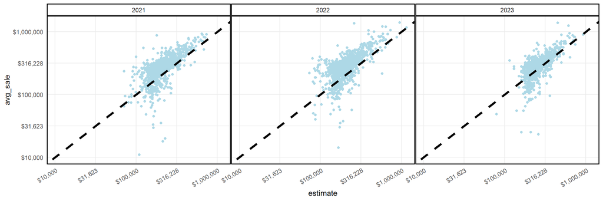

```r
# Want the figure to be square, so width is 3x the height

est_tbl <- join_tbl %>%
  group_by(pin, year) %>%
  summarize(avg_sale = mean(sale_price),
            certified = mean(certified_tot)) %>%
  # These are residential properties in cook county so, assessed value is 10% of estimate
  mutate(estimate = certified / 0.1)

# dplyr gets mad about $ syntax now, but pull isn't exactly eloquent
min_l <- min(pull(est_tbl, estimate), pull(est_tbl, avg_sale), na.rm=T)

# Figuring out scale range took too long
scale_range = c(min_l, NA)
scale_range = c(10000, NA)

more_labs = scales::trans_breaks("log10", function(x) 10^x)

scale_args <- list(labels = scales::dollar,
                   limits = scale_range,
                   breaks = more_labs,
                   minor_breaks = NULL)

saveRDS(scale_args, "part1_scale_args.rds")

sale_v_est <-
  est_tbl %>%
    ggplot(aes(x = estimate,
               y = avg_sale)) +
    geom_point(color = "lightblue") +
    geom_abline(slope = 1, intercept = 0,
                linetype = "dashed", linewidth = 1.5) +
    do.call(scale_x_log10, scale_args) +
    do.call(scale_y_log10, scale_args) +
    theme_minimal() +
    theme(legend.position = "bottom",
          panel.spacing = unit(0.05, "lines"),
          panel.border = element_rect(color = "black", fill = NA, linewidth = 1),
          strip.background = element_rect(color = "black", linewidth = 1)) +
    facet_wrap(~year, nrow = 1) +
    guides(x = guide_axis(angle = 30))

sale_v_est
```

## Section C

Explore trends and relationships with property sales using simple regressions

### Final Join Table

Joining on assessments for part two because most properties were not sold.

```r
# proviso_assess %>% glimpse()
# simple_sales %>% glimpse()
# simple_char %>% glimpse()
# simple_geo %>% glimpse()

join_tbl2 <- proviso_assess %>%
    left_join(simple_sales, by = c('pin' = 'pin',
                                   'tax_year' = 'year',
                                   'class' = 'class')) %>%
    # joining the bottom two on class but not year may cause issues
    left_join(simple_char, by = c('pin' = 'pin',
                                  'class' = 'class')) %>%
    left_join(simple_geo, by = c('pin' = 'pin',
                                 'class' = 'class',
                                 'nbhd_code' = 'nbhd_code'))
```

#### Skim Results

```r
join_tbl2 %>% skim()
```

Data summary

| Name | Piped data |
| --- | --- |
| Number of rows | 107703 |
| Number of columns | 62 |
| _______________________ |  |
| Column type frequency: |  |
| character | 31 |
| numeric | 31 |
| ________________________ |  |
| Group variables | None |

**Variable type: character**

| skim_variable | n_missing | complete_rate | min | max | empty | n_unique | whitespace |
| --- | --- | --- | --- | --- | --- | --- | --- |
| pin | 0 | 1.00 | 14 | 14 | 0 | 35917 | 0 |
| class | 0 | 1.00 | 3 | 3 | 0 | 10 | 0 |
| nbhd_code | 104347 | 0.03 | 5 | 5 | 0 | 32 | 0 |
| doc_no | 104347 | 0.03 | 10 | 10 | 0 | 3356 | 0 |
| deed_type | 104414 | 0.03 | 5 | 13 | 0 | 3 | 0 |
| mydec_deed_type | 104351 | 0.03 | 5 | 21 | 0 | 12 | 0 |
| seller_name | 104349 | 0.03 | 3 | 453 | 0 | 3194 | 0 |
| buyer_name | 104347 | 0.03 | 3 | 304 | 0 | 3287 | 0 |
| cdu | 898 | 0.99 | 2 | 2 | 0 | 5 | 0 |
| char_type_resd | 799 | 0.99 | 7 | 11 | 0 | 5 | 0 |
| char_cnst_qlty | 799 | 0.99 | 4 | 7 | 0 | 3 | 0 |
| char_apts | 813 | 0.99 | 3 | 5 | 0 | 4 | 0 |
| char_attic_fnsh | 827 | 0.99 | 4 | 11 | 0 | 3 | 0 |
| char_gar1_att | 827 | 0.99 | 2 | 3 | 0 | 2 | 0 |
| char_gar1_area | 827 | 0.99 | 2 | 3 | 0 | 2 | 0 |
| char_gar1_size | 830 | 0.99 | 6 | 8 | 0 | 8 | 0 |
| char_gar1_cnst | 8750 | 0.92 | 5 | 15 | 0 | 4 | 0 |
| char_attic_type | 799 | 0.99 | 4 | 7 | 0 | 3 | 0 |
| char_bsmt | 800 | 0.99 | 4 | 7 | 0 | 4 | 0 |
| char_ext_wall | 799 | 0.99 | 5 | 15 | 0 | 4 | 0 |
| char_heat | 799 | 0.99 | 4 | 16 | 0 | 4 | 0 |
| char_repair_cnd | 799 | 0.99 | 7 | 13 | 0 | 3 | 0 |
| char_bsmt_fin | 902 | 0.99 | 9 | 15 | 0 | 3 | 0 |
| char_roof_cnst | 799 | 0.99 | 4 | 17 | 0 | 6 | 0 |
| char_use | 799 | 0.99 | 12 | 13 | 0 | 2 | 0 |
| char_site | 799 | 0.99 | 19 | 21 | 0 | 3 | 0 |
| char_renovation | 813 | 0.99 | 2 | 3 | 0 | 2 | 0 |
| char_porch | 810 | 0.99 | 4 | 16 | 0 | 3 | 0 |
| char_air | 799 | 0.99 | 11 | 14 | 0 | 2 | 0 |
| char_tp_plan | 799 | 0.99 | 4 | 10 | 0 | 3 | 0 |
| tieback_key_pin | 101060 | 0.06 | 14 | 14 | 0 | 1098 | 0 |

**Variable type: numeric**

| skim_variable | n_missing | complete_rate | mean | sd | p0 | p25 | p50 | p75 | p100 | hist |
| --- | --- | --- | --- | --- | --- | --- | --- | --- | --- | --- |
| tax_year | 0 | 1.00 | 2022.00 | 0.82 | 2021.00 | 2021.00 | 2022.00 | 2023.00 | 2.02300e+03 | ▇▁▇▁▇ |
| mailed_bldg | 0 | 1.00 | 18793.94 | 8972.56 | 436.00 | 13932.00 | 16951.00 | 21278.50 | 1.38471e+05 | ▇▁▁▁▁ |
| mailed_land | 0 | 1.00 | 3652.95 | 1508.01 | 0.00 | 2680.00 | 3438.00 | 4318.00 | 8.84840e+04 | ▇▁▁▁▁ |
| mailed_tot | 0 | 1.00 | 22446.88 | 9883.91 | 1787.00 | 16876.00 | 20612.00 | 25001.00 | 1.57652e+05 | ▇▁▁▁▁ |
| certified_bldg | 0 | 1.00 | 18731.16 | 8875.54 | 436.00 | 13911.00 | 16921.00 | 21222.00 | 1.38471e+05 | ▇▁▁▁▁ |
| certified_land | 0 | 1.00 | 3652.95 | 1508.01 | 0.00 | 2680.00 | 3438.00 | 4318.00 | 8.84840e+04 | ▇▁▁▁▁ |
| certified_tot | 0 | 1.00 | 22384.11 | 9789.88 | 1787.00 | 16845.00 | 20565.00 | 25001.00 | 1.57652e+05 | ▇▁▁▁▁ |
| board_bldg | 35879 | 0.67 | 16920.95 | 7690.69 | 436.00 | 12955.00 | 15310.50 | 18824.00 | 1.37466e+05 | ▇▁▁▁▁ |
| board_land | 35879 | 0.67 | 3411.08 | 1395.95 | 0.00 | 2546.00 | 3092.00 | 4020.00 | 7.75550e+04 | ▇▁▁▁▁ |
| board_tot | 35879 | 0.67 | 20332.03 | 8520.38 | 1787.00 | 15784.00 | 18367.00 | 22798.00 | 1.57652e+05 | ▇▁▁▁▁ |
| sale_date | 104347 | 0.03 | 1651691319.19 | 23909538.40 | 1609718400.00 | 1631232000.00 | 1651708800.00 | 1671062400.00 | 1.69560e+09 | ▆▇▇▆▆ |
| sale_price | 104347 | 0.03 | 290915.69 | 134242.14 | 100.00 | 220000.00 | 275000.00 | 335000.00 | 1.39900e+06 | ▇▇▁▁▁ |
| sale_filter_same_sale_within_365 | 104347 | 0.03 | 0.00 | 0.04 | 0.00 | 0.00 | 0.00 | 0.00 | 1.00000e+00 | ▇▁▁▁▁ |
| sale_filter_less_than_10k | 104347 | 0.03 | 0.00 | 0.03 | 0.00 | 0.00 | 0.00 | 0.00 | 1.00000e+00 | ▇▁▁▁▁ |
| sale_filter_deed_type | 104347 | 0.03 | 0.02 | 0.14 | 0.00 | 0.00 | 0.00 | 0.00 | 1.00000e+00 | ▇▁▁▁▁ |
| card | 799 | 0.99 | 1.00 | 0.01 | 1.00 | 1.00 | 1.00 | 1.00 | 2.00000e+00 | ▇▁▁▁▁ |
| tieback_proration_rate | 799 | 0.99 | 0.97 | 0.13 | 0.00 | 1.00 | 1.00 | 1.00 | 1.00000e+00 | ▁▁▁▁▇ |
| card_proration_rate | 913 | 0.99 | 0.03 | 0.13 | 0.00 | 0.00 | 0.00 | 0.00 | 9.50000e-01 | ▇▁▁▁▁ |
| pin_is_multiland | 810 | 0.99 | 0.00 | 0.01 | 0.00 | 0.00 | 0.00 | 0.00 | 1.00000e+00 | ▇▁▁▁▁ |
| pin_num_landlines | 810 | 0.99 | 1.00 | 0.01 | 1.00 | 1.00 | 1.00 | 1.00 | 2.00000e+00 | ▇▁▁▁▁ |
| char_yrblt | 799 | 0.99 | 1945.20 | 20.28 | 1814.00 | 1928.00 | 1952.00 | 1956.00 | 2.02300e+03 | ▁▁▃▇▁ |
| char_bldg_sf | 799 | 0.99 | 1341.64 | 472.05 | 0.00 | 1018.00 | 1211.00 | 1547.00 | 5.72800e+03 | ▆▇▁▁▁ |
| char_land_sf | 812 | 0.99 | 5995.02 | 2421.04 | 610.00 | 4612.00 | 6215.00 | 6700.00 | 2.21211e+05 | ▇▁▁▁▁ |
| char_beds | 799 | 0.99 | 3.04 | 0.75 | 1.00 | 3.00 | 3.00 | 3.00 | 9.00000e+00 | ▂▇▁▁▁ |
| char_rooms | 799 | 0.99 | 5.87 | 1.26 | 2.00 | 5.00 | 6.00 | 7.00 | 1.50000e+01 | ▁▇▁▁▁ |
| char_fbath | 802 | 0.99 | 1.29 | 0.51 | 1.00 | 1.00 | 1.00 | 2.00 | 9.00000e+00 | ▇▁▁▁▁ |
| char_hbath | 892 | 0.99 | 0.36 | 0.50 | 0.00 | 0.00 | 0.00 | 1.00 | 5.00000e+00 | ▇▁▁▁▁ |
| char_frpl | 870 | 0.99 | 0.19 | 0.44 | 0.00 | 0.00 | 0.00 | 0.00 | 5.00000e+00 | ▇▁▁▁▁ |
| recent_renovation | 799 | 0.99 | 0.00 | 0.07 | 0.00 | 0.00 | 0.00 | 0.00 | 1.00000e+00 | ▇▁▁▁▁ |
| lon | 104388 | 0.03 | -87.87 | 0.03 | -87.92 | -87.89 | -87.87 | -87.85 | -8.78000e+01 | ▃▇▇▅▂ |
| lat | 104388 | 0.03 | 41.86 | 0.02 | 41.82 | 41.84 | 41.87 | 41.88 | 4.19100e+01 | ▅▅▆▇▃ |

#### Glimpse of Variables

Using variable list to build out first model, understanding which are string vs numeric variables.

```r
# Glimpsing variables to develop first model
join_tbl2 %>% glimpse()
```

```
## Rows: 107,703
## Columns: 62
## $ pin                              <chr> "15021060110000", "15021070340000", "…
## $ tax_year                         <dbl> 2021, 2021, 2021, 2021, 2021, 2021, 2…
## $ class                            <chr> "234", "205", "205", "205", "205", "2…
## $ mailed_bldg                      <dbl> 10040, 18815, 13437, 12949, 18145, 19…
## $ mailed_land                      <dbl> 3900, 3912, 1595, 3310, 5469, 3900, 3…
## $ mailed_tot                       <dbl> 13940, 22727, 15032, 16259, 23614, 23…
## $ certified_bldg                   <dbl> 10040, 18815, 13437, 12949, 18145, 19…
## $ certified_land                   <dbl> 3900, 3912, 1595, 3310, 5469, 3900, 3…
## $ certified_tot                    <dbl> 13940, 22727, 15032, 16259, 23614, 23…
## $ board_bldg                       <dbl> 10040, 18815, 13437, 11902, 18145, 19…
## $ board_land                       <dbl> 3900, 3912, 1595, 3310, 5469, 3900, 3…
## $ board_tot                        <dbl> 13940, 22727, 15032, 15212, 23614, 23…
## $ nbhd_code                        <chr> NA, NA, NA, NA, NA, NA, NA, NA, NA, N…
```

[output cut: 49 more lines]

```r
# saving object to use in part 2 markdown file
join_tbl2 %>% saveRDS('part1_join_tbl2.rds')
```

```r
knitr::opts_chunk$set(warning = FALSE, message = FALSE)
library(tidyverse)
library(RSQLite)
library(skimr)
library(cmfproperty)
library(tidymodels)
library(corrr)
library(DT)
library(stargazer)
library(ranger)

#devtools::install_github("cmf-uchicago/cmfproperty")

options(DT.options = list(dom = 't',
                          scrollX = TRUE,
                          scrollCollapse = TRUE
                          ))
```

```r
# join2_select <-
#   readRDS('part1_join2_select.rds')

join_tbl2 <-
  readRDS('part1_join_tbl2.rds')
```

# Part 2

## Part A - Introduction

### Background

To facilitate the fair execution of the property tax system, the Cook County Assessor’s office assesses the market value of every property in Cook County through over a triennial cycle. From known characteristics of properties sold, the assessor’s office models the market value of all properties whether or not they were recently sold. However, there are limitations with any estimation attempt due to incomplete knowledge and the natural tendency of models to estimate towards the average.

### Visualizations

3 to 4 graphs with descriptive captions which include information on sale price, assessment accuracy, and outliers. Generally focus on single family homes and arm’s length transactions. Are there data you would exclude?

I’m not sure how to identify non-arm’s length transactions.

Of the 200 level regression classes, only 210, 211, 212 and 295 could be a multi-family home (MFH). However, none are included in the Proviso records.

```r
join_tbl2 %>%
  filter(!is.na(sale_price)) %>%
  sample_n(10) %>%
  DT::datatable()
```

|  | pin | tax_year | class | mailed_bldg | mailed_land | mailed_tot | certified_bldg | certified_land | certified_tot | board_bldg | board_land | board_tot | nbhd_code | sale_date | sale_price | doc_no | deed_type | mydec_deed_type | seller_name | buyer_name | sale_filter_same_sale_within_365 | sale_filter_less_than_10k | sale_filter_deed_type | card | tieback_proration_rate | card_proration_rate | cdu | pin_is_multiland | pin_num_landlines | … |
| --- | --- | --- | --- | --- | --- | --- | --- | --- | --- | --- | --- | --- | --- | --- | --- | --- | --- | --- | --- | --- | --- | --- | --- | --- | --- | --- | --- | --- | --- | --- |
| 1 | 15213110110000 | 2022 | 205 | 18340 | 3990 | 22330 | 18340 | 3990 | 22330 | 18340 | 3990 | 22330 | 31110 | 1655769600 | 329900 | 2218901240 | Trustee Deed | Trustee Deed | LORI-JO FERLE, AS SUCCESSOR NTRUSTEE | ANNA L HERRIOTT | 0 | 0 | 0 | 1 | 1 | 0 | AV | 0 | 1 | … |
| 2 | 15344140300000 | 2021 | 203 | 22395 | 4063 | 26458 | 22395 | 4063 | 26458 | 22395 | 4063 | 26458 | 31160 | 1626393600 | 536000 | 2123717344 | Warranty Deed | Warranty Deed | ERIC DEUTSCH | ELIZABETH ANN CARIK | 0 | 0 | 0 | 1 | 1 | 0 | AV | 0 | 1 | … |
| 3 | 15134010180000 | 2021 | 203 | 20667 | 2695 | 23362 | 20667 | 2695 | 23362 | 20667 | 2695 | 23362 | 31092 | 1638748800 | 250000 | 2135639050 | Trustee Deed | Trustee Deed | CHICAGO TITLE LAND TRUST COMPANY AS SUCCESSOR TRUSTEE | ALESIA S. MARSHALL | 0 | 0 | 0 | 1 | 1 | 0 | AV | 0 | 1 | … |
| 4 | 15324100080000 | 2023 | 205 | 41350 | 6650 | 48000 | 41350 | 6650 | 48000 |  |  |  | 31152 | 1678406400 | 438500 | 2308233209 | Other | Special Warranty Deed | DEUTSCHE BANK NATIONAL TRUST COMPANY, AS TRUSTEE, IN TRUST FOR REGISTERED HOLDERS OF LONG BEACH MORTGAGE LOAN TRUST 2006-5, ASSET-BACKED CERTIFICATES, SERIES 2006-5 | MATTHEW P WALSH II | 0 | 0 | 0 | 1 | 1 | 0 | AV | 0 | 1 | … |
| 5 | 15343300180000 | 2021 | 203 | 17871 | 4875 | 22746 | 17871 | 4875 | 22746 | 17871 | 4875 | 22746 | 31160 | 1619136000 | 20000 | 2218615035 |  | Quit Claim Deed | DAVID A. PEKLO | DAWN M. HANSON | 0 | 0 | 1 | 1 | 1 | 0 | AV | 0 | 1 | … |
| 6 | 15242070340000 | 2022 | 202 | 17917 | 1797 | 19714 | 17917 | 1797 | 19714 | 17917 | 1797 | 19714 | 31092 | 1649116800 | 315000 | 2211901223 | Warranty Deed | Warranty Deed | ARNIE RIPPENER | ROBERT SCHULER | 0 | 0 | 0 | 1 | 1 | 0 | AV | 0 | 1 | … |
| 7 | 15111210070000 | 2023 | 205 | 20100 | 2900 | 23000 | 20100 | 2900 | 23000 |  |  |  | 31040 | 1689120000 | 500000 | 2321449238 | Warranty Deed | Warranty Deed | BE WISE HOLDINGS LLC | VANESSA SHERWOOD | 0 | 0 | 0 | 1 | 1 | 0 | AV | 0 | 1 | … |
| 8 | 15201150520000 | 2023 | 202 | 17625 | 4375 | 22000 | 17625 | 4375 | 22000 |  |  |  | 31110 | 1681689600 | 280000 | 2311125008 | Warranty Deed | Warranty Deed | ANTHONY DESANTO | JUAN CARLOS MERA PEREZ | 0 | 0 | 0 | 1 | 1 | 0 | AV | 0 | 1 | … |
| 9 | 15331260190000 | 2021 | 205 | 42002 | 5469 | 47471 | 42002 | 5469 | 47471 | 42002 | 5469 | 47471 | 31151 | 1616457600 | 555000 | 2109907098 | Warranty Deed | Warranty Deed | PETER KASS | JOHN HAYES | 0 | 0 | 0 | 1 | 1 | 0 | AV | 0 | 1 | … |
| 10 | 15091030320000 | 2021 | 202 | 12509 | 2406 | 14915 | 12509 | 2406 | 14915 | 12509 | 2406 | 14915 | 31020 | 1626393600 | 205000 | 2128807849 | Warranty Deed | Warranty Deed | LUIS FERNANDO ANDRADE | ADRIANA RODRIGUEZ | 0 | 0 | 0 | 1 | 1 | 0 | AV | 0 | 1 | … |

```r
ratios <- cmfproperty::reformat_data(
  join_tbl2 %>%
    mutate(assessed_value = if_else(tax_year == 2023, 10*certified_tot, 10*board_tot)) %>%
    filter(!is.na(sale_price)) ,
  'sale_price',
  'assessed_value',
  'tax_year',
   filter_data = FALSE
)
```

```
## [1] "Inflation adjusted to 2021"
```

```r
min_yr <- 2021
max_yr <- 2023

filtered_ratios <-
  subset(ratios, ratios$arms_length_transaction != 1)

stats <- cmfproperty::calc_iaao_stats(filtered_ratios)

output <- cmfproperty::diagnostic_plots(ratios = ratios,
                                        stats = stats,
                                        min_reporting_yr = min_yr,
                                        max_reporting_yr = max_yr)

ratios %>% as_tibble() %>% glimpse()
```

```
## Rows: 3,356
## Columns: 68
## $ pin                              <chr> "15051140130000", "15043090010000", "…
## $ SALE_YEAR                        <dbl> 2021, 2021, 2021, 2021, 2021, 2021, 2…
## $ class                            <chr> "202", "202", "204", "202", "205", "2…
## $ mailed_bldg                      <dbl> 13918, 12345, 20359, 14782, 19221, 19…
## $ mailed_land                      <dbl> 3273, 3267, 4264, 2663, 3912, 4024, 3…
## $ mailed_tot                       <dbl> 17191, 15612, 24623, 17445, 23133, 23…
## $ certified_bldg                   <dbl> 13918, 12345, 20359, 14782, 19221, 19…
## $ certified_land                   <dbl> 3273, 3267, 4264, 2663, 3912, 4024, 3…
## $ certified_tot                    <dbl> 17191, 15612, 24623, 17445, 23133, 23…
## $ board_bldg                       <dbl> 13918, 12345, 20359, 14782, 19221, 19…
## $ board_land                       <dbl> 3273, 3267, 4264, 2663, 3912, 4024, 3…
## $ board_tot                        <dbl> 17191, 15612, 24623, 17445, 23133, 23…
## $ nbhd_code                        <chr> "31010", "31200", "31010", "31080", "…
```

[output cut: 55 more lines]

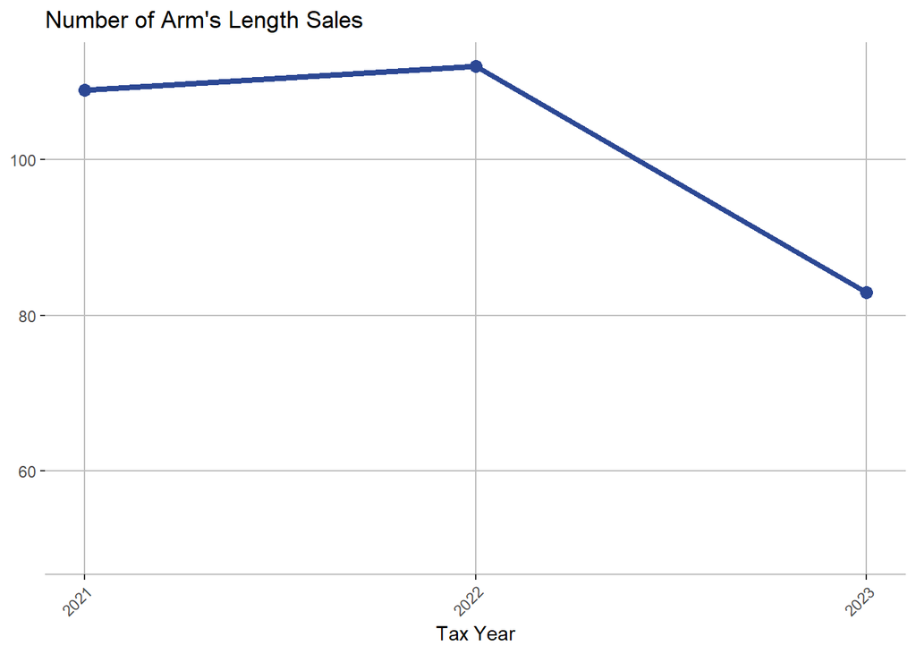

```r
output[[1]]
```

```r
ratios %>%
  summarize(sum(arms_length_transaction, na.rm = T),
            n()) %>%
  DT::datatable()
```

|  | sum(arms_length_transaction, na.rm = T) | n() |
| --- | --- | --- |
| 1 | 3049 | 3356 |

```r
# can't tell how it determines arms length transactions
ratios %>%
  as_tibble() %>%
  group_by(arms_length_transaction) %>%
  slice_sample(n = 10, replace = F) %>%
  DT::datatable()
```

|  | pin | SALE_YEAR | class | mailed_bldg | mailed_land | mailed_tot | certified_bldg | certified_land | certified_tot | board_bldg | board_land | board_tot | nbhd_code | sale_date | SALE_PRICE | doc_no | deed_type | mydec_deed_type | seller_name | buyer_name | sale_filter_same_sale_within_365 | sale_filter_less_than_10k | sale_filter_deed_type | card | tieback_proration_rate | card_proration_rate | cdu | pin_is_multiland | pin_num_landlines | … |
| --- | --- | --- | --- | --- | --- | --- | --- | --- | --- | --- | --- | --- | --- | --- | --- | --- | --- | --- | --- | --- | --- | --- | --- | --- | --- | --- | --- | --- | --- | --- |
| 1 | 15093150750000 | 2023 | 203 | 15485 | 4515 | 20000 | 15485 | 4515 | 20000 |  |  |  | 31020 | 1675641600 | 130000 | 2312946067 | Warranty Deed | Warranty Deed | SECOND CITY RENEWAL LLC | SURMAC BUILDERS LLC | 0 | 0 | 0 | 1 | 1 | 0 | AV | 0 | 1 | … |
| 2 | 15091020350000 | 2021 | 202 | 12191 | 2406 | 14597 | 12191 | 2406 | 14597 | 12191 | 2406 | 14597 | 31020 | 1611878400 | 105000 | 2105320131 | Warranty Deed | Warranty Deed | GRANDVIEW CAPITAL LLC | OMAR PEREZ RODRIGUEZ | 0 | 0 | 0 | 1 | 1 | 0 | AV | 0 | 1 | … |
| 3 | 15103010240000 | 2022 | 203 | 13384 | 1739 | 15123 | 13384 | 1739 | 15123 | 13384 | 1739 | 15123 | 31060 | 1658102400 | 84500 | 2220339062 | Other | Special Warranty Deed | CORTEZZ, LLC | ISMAEL MIRANDA | 0 | 0 | 0 | 1 | 1 | 0 | AV | 0 | 1 | … |
| 4 | 15111210070000 | 2021 | 205 | 12803 | 2505 | 15308 | 12803 | 2505 | 15308 | 12803 | 2505 | 15308 | 31040 | 1614729600 | 62000 | 2110528088 | Other | Special Warranty Deed | COUNTY OF COOK, ILLINOIS, A BODY POLITIC AND CORPORATE, D/B/A COOK COUNTY LAND BANK AUTHORITY | BE WISE HOLDINGS, LLC | 0 | 0 | 0 | 1 | 1 | 0 | AV | 0 | 1 | … |
| 5 | 15342070030000 | 2021 | 202 | 16930 | 2930 | 19860 | 16930 | 2930 | 19860 | 16930 | 2930 | 19860 | 31210 | 1627257600 | 135000 | 2121642173 | Warranty Deed | Warranty Deed | MISC 004, LLC | CIBROOK LTD | 0 | 0 | 0 |  |  |  |  |  |  | … |
| 6 | 15152320150000 | 2022 | 203 | 13717 | 1848 | 15565 | 13717 | 1848 | 15565 | 13717 | 1848 | 15565 | 31031 | 1646697600 | 86000 | 2232110077 | Other | Judicial Sale | THE JUDICIAL SALES CORPORATION | SYED VENTURES LLC | 0 | 0 | 0 | 1 | 1 | 0 | AV | 0 | 1 | … |
| 7 | 15073030690000 | 2021 | 203 | 13634 | 2969 | 16603 | 13634 | 2969 | 16603 | 13634 | 2969 | 16603 | 31080 | 1638316800 | 115000 | 2204039101 | Warranty Deed | Warranty Deed | TERRY J. WEIBERG | C &amp; N CONSTRUCTION, INC. | 0 | 0 | 0 | 1 | 1 | 0 | AV | 0 | 1 | … |
| 8 | 15153130290000 | 2022 | 203 | 13438 | 2546 | 15984 | 13438 | 2546 | 15984 | 13438 | 2546 | 15984 | 31034 | 1670803200 | 123600 | 2234933126 | Warranty Deed | Warranty Deed | CHICAGO TITLE LAND TRUST, AS SUCCESSOR TRUSTEE UNDER THE PROVISIONS OF A DEED OR DEEDS IN TRUST, DULY RECORDED AND DELIVERED TO SAID COMPANY IN PURSUANCE OF A TRUST AGREEMENT DATED MARCH 24, 2003 AND … | JENNIFER BLANCAS | 0 | 0 | 0 | 1 | 1 | 0 | AV | 0 | 1 | … |
| 9 | 15153120320000 | 2021 | 203 | 12331 | 3485 | 15816 | 12331 | 3485 | 15816 | 12331 | 3485 | 15816 | 31034 | 1632182400 | 85000 | 2207039449 | Warranty Deed | Warranty Deed | 1ST MIDWEST FINANCIAL, INC. | KOBY REIL, LLC | 0 | 0 | 0 | 1 | 1 | 0 | AV | 0 | 1 | … |
| 10 | 15174020370000 | 2023 | 204 | 20638 | 5363 | 26001 | 20638 | 5363 | 26001 |  |  |  | 31080 | 1686700800 | 165000 | 2317906110 | Warranty Deed | Warranty Deed | ALAN E BARTHOLD | EDGAR H SANDOVAL | 0 | 0 | 0 | 1 | 1 | 0 | AV | 0 | 1 | … |

[output cut: 13 more lines]

Normally distributed

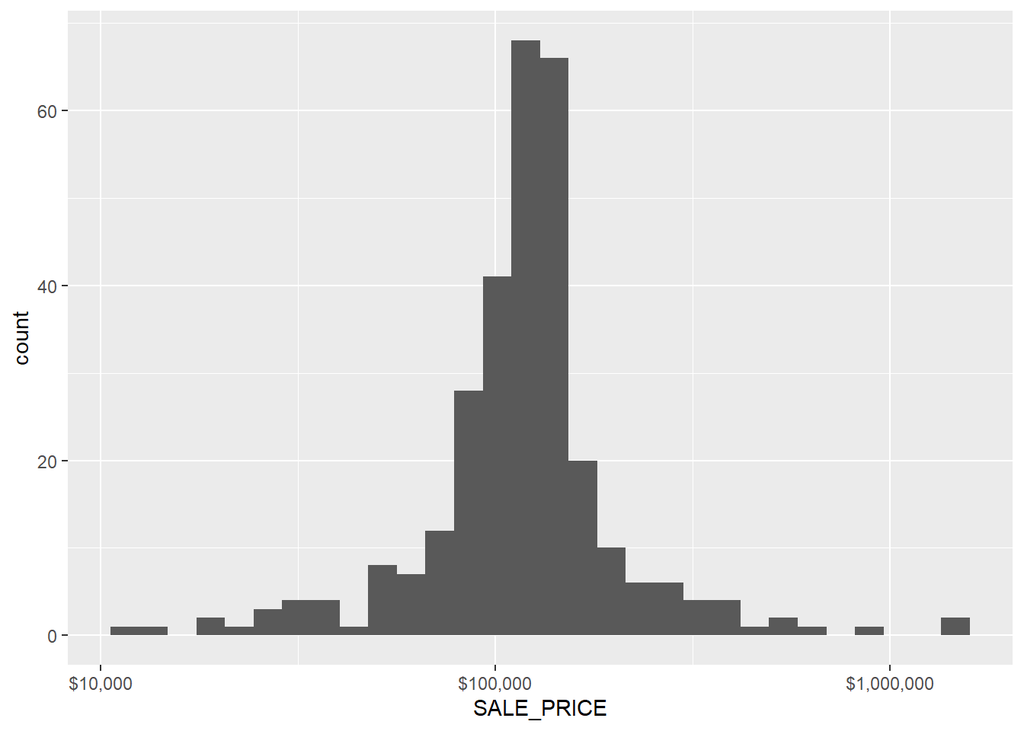

```r
filtered_ratios %>%
  ggplot(aes(x=SALE_PRICE)) +
  geom_histogram() +
  scale_x_log10(labels = scales::dollar)
```

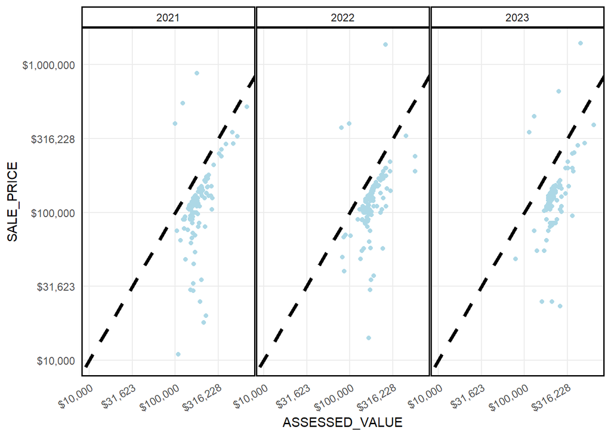

```r
scale_args <- readRDS('part1_scale_args.rds')

filtered_ratios %>%
    ggplot(aes(x = ASSESSED_VALUE,
               y = SALE_PRICE)) +
    geom_point(color = "lightblue") +
    geom_abline(slope = 1, intercept = 0,
                linetype = "dashed", linewidth = 1.5) +
    do.call(scale_x_log10, scale_args) +
    do.call(scale_y_log10, scale_args) +
    theme_minimal() +
    theme(legend.position = "bottom",
          panel.spacing = unit(0.05, "lines"),
          panel.border = element_rect(color = "black", fill = NA, linewidth = 1),
          strip.background = element_rect(color = "black", linewidth = 1)) +
    facet_wrap(~SALE_YEAR, nrow = 1) +
    guides(x = guide_axis(angle = 30))
```

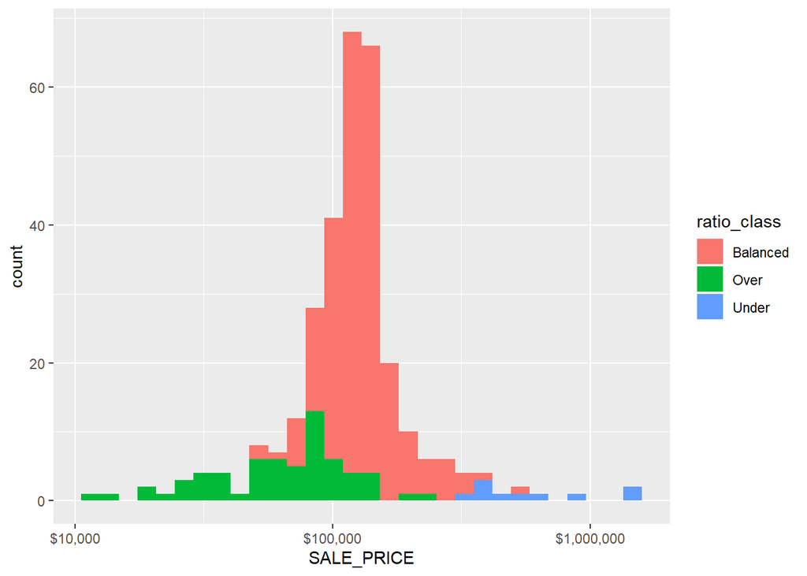

```r
filtered_ratios %>%
  #filter(RATIO >= 2 | RATIO <= 0.5) %>%
  mutate(ratio_class = case_when(RATIO >= 2 ~  "Over",
                                 RATIO <= 0.5 ~ "Under",
                                 TRUE ~ "Balanced")) %>%
#  as_tibble()

  ggplot(aes(x=SALE_PRICE, fill = ratio_class)) +
  geom_histogram() +
  scale_x_log10(labels = scales::dollar)
```

[figure not shown]

```r
#remotes::install_github("coolbutuseless/ggpattern")
library(ggpattern)


# Define the breaks for binning SALE_PRICE
breaks <- c(0, 5e4, 1e5, 2e5, 5e5, 1e6, Inf)
break_level <- c(25e3, 5e4, 1e5, 25e4, 5e5, 1e6)
break_lbl <- c("0-50k", "50k-100k", "100k-200k", "200k-500k", "500k-1m", "1m+")

filtered_ratios %>%
  mutate(
    sale_price_range = cut(SALE_PRICE, breaks, labels = break_lbl),
    diff = ASSESSED_VALUE - SALE_PRICE
  ) %>%
  group_by(sale_price_range) %>%
  summarise(total_diff = sum(diff)) %>%
  ggplot(aes(x = sale_price_range, y = total_diff)) +
  geom_col() +
  geom_col_pattern(
    aes(y = break_level),
    pattern = 'stripe',
    pattern_spacing  = 0.01,
    fill = 'red',
    #color = "red",
    alpha = 0.5) +
  scale_x_discrete(labels = break_lbl) +
  scale_y_continuous(labels = scales::dollar) +
  labs(x = "Sale Price Range", y = "Total Difference")
```

## Part C - Workflow: Regression Model

```r
model_tb <-
  join_tbl2 %>%
    filter(sale_filter_less_than_10k == 0,
         sale_filter_deed_type == 0) %>%
    #select(!any_of(sale_col)) %>%
    mutate(sold = !is.na(sale_price))

#saveRDS(model_tb, 'part2_model_tb.rds')

sold_model_tb <-
  model_tb %>%
    filter(sold == TRUE)

#saveRDS(sold_model_tb, 'part2_sold_model_tb.rds')

sold_model_tb %>%
  skim() %>% view()
```

```r
# RSME: 24015 with 5 folds
model_sold <-
  sold_model_tb %>%
  # leaving these in bc explictly naming predictors
  # select(!c(
  #   board_bldg, board_land, board_tot,
  #   mailed_bldg, mailed_land, mailed_tot,
  #   certified_bldg, certified_land, certified_tot,
  #   sold)) %>%
  mutate(log_sale_price = log(sale_price)) %>%
  # selecting out high missing variable
  select(!tieback_key_pin)

model_assess_23 <-
  model_sold %>%
    filter(tax_year < 2023) %>%
    # drop numeric na columns bc step_unknown doesn't handle numeric
    filter_if(is.numeric, ~!is.na(.))

model_assess_23 %>%
  skim()
```

Data summary

| Name | Piped data |
| --- | --- |
| Number of rows | 2425 |
| Number of columns | 63 |
| _______________________ |  |
| Column type frequency: |  |
| character | 30 |
| logical | 1 |
| numeric | 32 |
| ________________________ |  |
| Group variables | None |

**Variable type: character**

| skim_variable | n_missing | complete_rate | min | max | empty | n_unique | whitespace |
| --- | --- | --- | --- | --- | --- | --- | --- |
| pin | 0 | 1.00 | 14 | 14 | 0 | 2284 | 0 |
| class | 0 | 1.00 | 3 | 3 | 0 | 10 | 0 |
| nbhd_code | 0 | 1.00 | 5 | 5 | 0 | 32 | 0 |
| doc_no | 0 | 1.00 | 10 | 10 | 0 | 2425 | 0 |
| deed_type | 0 | 1.00 | 5 | 13 | 0 | 3 | 0 |
| mydec_deed_type | 3 | 1.00 | 5 | 21 | 0 | 9 | 0 |
| seller_name | 1 | 1.00 | 3 | 380 | 0 | 2329 | 0 |
| buyer_name | 0 | 1.00 | 3 | 168 | 0 | 2387 | 0 |
| cdu | 0 | 1.00 | 2 | 2 | 0 | 2 | 0 |
| char_type_resd | 0 | 1.00 | 7 | 11 | 0 | 4 | 0 |
| char_cnst_qlty | 0 | 1.00 | 4 | 7 | 0 | 3 | 0 |
| char_apts | 0 | 1.00 | 3 | 4 | 0 | 2 | 0 |
| char_attic_fnsh | 0 | 1.00 | 4 | 11 | 0 | 2 | 0 |
| char_gar1_att | 0 | 1.00 | 2 | 3 | 0 | 2 | 0 |
| char_gar1_area | 0 | 1.00 | 2 | 3 | 0 | 2 | 0 |
| char_gar1_size | 4 | 1.00 | 6 | 8 | 0 | 7 | 0 |
| char_gar1_cnst | 185 | 0.92 | 5 | 15 | 0 | 4 | 0 |
| char_attic_type | 0 | 1.00 | 4 | 7 | 0 | 3 | 0 |
| char_bsmt | 0 | 1.00 | 4 | 7 | 0 | 4 | 0 |
| char_ext_wall | 0 | 1.00 | 5 | 15 | 0 | 4 | 0 |
| char_heat | 0 | 1.00 | 15 | 16 | 0 | 3 | 0 |
| char_repair_cnd | 0 | 1.00 | 7 | 13 | 0 | 3 | 0 |
| char_bsmt_fin | 23 | 0.99 | 10 | 15 | 0 | 2 | 0 |
| char_roof_cnst | 0 | 1.00 | 4 | 17 | 0 | 6 | 0 |
| char_use | 0 | 1.00 | 12 | 13 | 0 | 2 | 0 |
| char_site | 0 | 1.00 | 19 | 21 | 0 | 3 | 0 |
| char_renovation | 0 | 1.00 | 2 | 3 | 0 | 2 | 0 |
| char_porch | 0 | 1.00 | 4 | 16 | 0 | 3 | 0 |
| char_air | 0 | 1.00 | 11 | 14 | 0 | 2 | 0 |
| char_tp_plan | 0 | 1.00 | 4 | 10 | 0 | 3 | 0 |

**Variable type: logical**

| skim_variable | n_missing | complete_rate | mean | count |
| --- | --- | --- | --- | --- |
| sold | 0 | 1 | 1 | TRU: 2425 |

**Variable type: numeric**

| skim_variable | n_missing | complete_rate | mean | sd | p0 | p25 | p50 | p75 | p100 | hist |
| --- | --- | --- | --- | --- | --- | --- | --- | --- | --- | --- |
| tax_year | 0 | 1 | 2021.52 | 0.50 | 2021.00 | 2021.00 | 2022.00 | 2022.00 | 2022.00 | ▇▁▁▁▇ |
| mailed_bldg | 0 | 1 | 18102.86 | 7892.40 | 2772.00 | 13779.00 | 16163.00 | 19828.00 | 109500.00 | ▇▁▁▁▁ |
| mailed_land | 0 | 1 | 3569.37 | 1346.67 | 508.00 | 2673.00 | 3300.00 | 4080.00 | 16345.00 | ▇▆▁▁▁ |
| mailed_tot | 0 | 1 | 21672.23 | 8638.05 | 7112.00 | 16674.00 | 19714.00 | 23687.00 | 115125.00 | ▇▁▁▁▁ |
| certified_bldg | 0 | 1 | 18061.78 | 7810.05 | 2772.00 | 13750.00 | 16163.00 | 19813.00 | 109500.00 | ▇▁▁▁▁ |
| certified_land | 0 | 1 | 3569.37 | 1346.67 | 508.00 | 2673.00 | 3300.00 | 4080.00 | 16345.00 | ▇▆▁▁▁ |
| certified_tot | 0 | 1 | 21631.15 | 8556.86 | 7088.00 | 16655.00 | 19714.00 | 23676.00 | 115125.00 | ▇▁▁▁▁ |
| board_bldg | 0 | 1 | 17973.14 | 7745.35 | 1867.00 | 13704.00 | 16121.00 | 19736.00 | 109500.00 | ▇▁▁▁▁ |
| board_land | 0 | 1 | 3569.37 | 1346.67 | 508.00 | 2673.00 | 3300.00 | 4080.00 | 16345.00 | ▇▆▁▁▁ |
| board_tot | 0 | 1 | 21542.51 | 8495.80 | 4750.00 | 16606.00 | 19652.00 | 23649.00 | 115125.00 | ▇▁▁▁▁ |
| sale_date | 0 | 1 | 1641443304.25 | 17476724.23 | 1609718400.00 | 1627516800.00 | 1642118400.00 | 1655942400.00 | 1672358400.00 | ▆▆▆▇▆ |
| sale_price | 0 | 1 | 288269.94 | 129715.86 | 25000.00 | 220000.00 | 270000.00 | 330000.00 | 1399000.00 | ▇▅▁▁▁ |
| sale_filter_same_sale_within_365 | 0 | 1 | 0.00 | 0.05 | 0.00 | 0.00 | 0.00 | 0.00 | 1.00 | ▇▁▁▁▁ |
| sale_filter_less_than_10k | 0 | 1 | 0.00 | 0.00 | 0.00 | 0.00 | 0.00 | 0.00 | 0.00 | ▁▁▇▁▁ |
| sale_filter_deed_type | 0 | 1 | 0.00 | 0.00 | 0.00 | 0.00 | 0.00 | 0.00 | 0.00 | ▁▁▇▁▁ |
| card | 0 | 1 | 1.00 | 0.00 | 1.00 | 1.00 | 1.00 | 1.00 | 1.00 | ▁▁▇▁▁ |
| tieback_proration_rate | 0 | 1 | 1.00 | 0.02 | 0.33 | 1.00 | 1.00 | 1.00 | 1.00 | ▁▁▁▁▇ |
| card_proration_rate | 0 | 1 | 0.00 | 0.01 | 0.00 | 0.00 | 0.00 | 0.00 | 0.60 | ▇▁▁▁▁ |
| pin_is_multiland | 0 | 1 | 0.00 | 0.00 | 0.00 | 0.00 | 0.00 | 0.00 | 0.00 | ▁▁▇▁▁ |
| pin_num_landlines | 0 | 1 | 1.00 | 0.00 | 1.00 | 1.00 | 1.00 | 1.00 | 1.00 | ▁▁▇▁▁ |
| char_yrblt | 0 | 1 | 1944.48 | 20.43 | 1836.00 | 1928.00 | 1951.00 | 1956.00 | 2022.00 | ▁▁▅▇▁ |
| char_bldg_sf | 0 | 1 | 1341.55 | 457.49 | 400.00 | 1024.00 | 1222.00 | 1531.00 | 5084.00 | ▇▅▁▁▁ |
| char_land_sf | 0 | 1 | 6211.33 | 1947.27 | 924.00 | 5000.00 | 6250.00 | 6800.00 | 30640.00 | ▇▂▁▁▁ |
| char_beds | 0 | 1 | 3.04 | 0.75 | 1.00 | 3.00 | 3.00 | 3.00 | 7.00 | ▃▇▃▁▁ |
| char_rooms | 0 | 1 | 5.93 | 1.30 | 3.00 | 5.00 | 6.00 | 7.00 | 13.00 | ▇▇▂▁▁ |
| char_fbath | 0 | 1 | 1.32 | 0.53 | 1.00 | 1.00 | 1.00 | 2.00 | 5.00 | ▇▃▁▁▁ |
| char_hbath | 0 | 1 | 0.37 | 0.51 | 0.00 | 0.00 | 0.00 | 1.00 | 3.00 | ▇▅▁▁▁ |
| char_frpl | 0 | 1 | 0.18 | 0.44 | 0.00 | 0.00 | 0.00 | 0.00 | 3.00 | ▇▂▁▁▁ |
| recent_renovation | 0 | 1 | 0.05 | 0.22 | 0.00 | 0.00 | 0.00 | 0.00 | 1.00 | ▇▁▁▁▁ |
| lon | 0 | 1 | -87.87 | 0.03 | -87.92 | -87.89 | -87.87 | -87.85 | -87.80 | ▃▆▇▅▂ |
| lat | 0 | 1 | 41.86 | 0.02 | 41.82 | 41.84 | 41.87 | 41.88 | 41.91 | ▅▅▆▇▃ |
| log_sale_price | 0 | 1 | 12.48 | 0.43 | 10.13 | 12.30 | 12.51 | 12.71 | 14.15 | ▁▁▇▇▁ |

```r
assess23_split <- initial_split(model_assess_23)

assess23_train <- training(assess23_split)
assess23_test  <- testing(assess23_split)

# # reduce folds to decrease time to fit
folds_assess23 <- vfold_cv(assess23_train, v=5)

rf_reg_recipe <-
  recipe(log_sale_price ~ # maybe include nbhd_code?
           class + cdu + pin_is_multiland + pin_num_landlines + char_yrblt +
           char_bldg_sf + char_land_sf + char_beds + char_rooms + char_fbath +
           char_hbath + char_frpl + char_type_resd + char_cnst_qlty +
           char_apts + char_attic_fnsh + char_gar1_att + char_gar1_area +
           char_gar1_size + char_gar1_cnst + char_attic_type + char_bsmt +
           char_ext_wall + char_heat + char_repair_cnd + char_bsmt_fin +
           char_roof_cnst + char_use + char_site + char_renovation +
           recent_renovation + char_porch + char_air + char_tp_plan,
         data = assess23_train) %>%
  step_novel(all_nominal_predictors()) %>%
  step_unknown(all_nominal_predictors()) %>%
  # this step requires string, factor, or ordered columns
  # step_unknown(all_predictors()) %>%
  step_dummy(all_nominal_predictors(), one_hot = T)

rf_reg_recipe %>%
  prep() %>%
  bake(assess23_train) %>%
  sample_n(10) %>%
  DT::datatable()
```

|  | pin_is_multiland | pin_num_landlines | char_yrblt | char_bldg_sf | char_land_sf | char_beds | char_rooms | char_fbath | char_hbath | char_frpl | recent_renovation | log_sale_price | class_X202 | class_X203 | class_X204 | class_X205 | class_X206 | class_X207 | class_X208 | class_X209 | class_X234 | class_X278 | class_new | class_unknown | cdu_AV | cdu_GD | cdu_new | cdu_unknown | char_type_resd_X1.Story | … |
| --- | --- | --- | --- | --- | --- | --- | --- | --- | --- | --- | --- | --- | --- | --- | --- | --- | --- | --- | --- | --- | --- | --- | --- | --- | --- | --- | --- | --- | --- | --- |
| 1 | 0 | 1 | 1950 | 1015 | 6650 | 2 | 4 | 1 | 0 | 0 | 0 | 12.46843690999767 | 0 | 1 | 0 | 0 | 0 | 0 | 0 | 0 | 0 | 0 | 0 | 0 | 1 | 0 | 0 | 0 | 1 | … |
| 2 | 0 | 1 | 1930 | 1448 | 4376 | 2 | 7 | 1 | 1 | 1 | 0 | 12.34583458790533 | 0 | 1 | 0 | 0 | 0 | 0 | 0 | 0 | 0 | 0 | 0 | 0 | 1 | 0 | 0 | 0 | 0 | … |
| 3 | 0 | 1 | 1953 | 864 | 6030 | 3 | 5 | 1 | 0 | 0 | 0 | 12.42921619684438 | 1 | 0 | 0 | 0 | 0 | 0 | 0 | 0 | 0 | 0 | 0 | 0 | 1 | 0 | 0 | 0 | 1 | … |
| 4 | 0 | 1 | 1925 | 1705 | 4148 | 4 | 9 | 2 | 1 | 0 | 0 | 11.4075649493124 | 0 | 0 | 0 | 1 | 0 | 0 | 0 | 0 | 0 | 0 | 0 | 0 | 1 | 0 | 0 | 0 | 0 | … |
| 5 | 0 | 1 | 1957 | 977 | 7150 | 3 | 6 | 1 | 0 | 0 | 0 | 12.32385568118656 | 1 | 0 | 0 | 0 | 0 | 0 | 0 | 0 | 0 | 0 | 0 | 0 | 1 | 0 | 0 | 0 | 1 | … |
| 6 | 0 | 1 | 1959 | 942 | 7535 | 3 | 6 | 1 | 1 | 1 | 0 | 12.82125828462041 | 0 | 0 | 0 | 0 | 0 | 0 | 0 | 0 | 1 | 0 | 0 | 0 | 1 | 0 | 0 | 0 | 0 | … |
| 7 | 0 | 1 | 1960 | 1246 | 6250 | 3 | 6 | 1 | 1 | 1 | 0 | 12.61818229635701 | 0 | 1 | 0 | 0 | 0 | 0 | 0 | 0 | 0 | 0 | 0 | 0 | 1 | 0 | 0 | 0 | 1 | … |
| 8 | 0 | 1 | 1957 | 1981 | 7000 | 4 | 7 | 2 | 1 | 0 | 0 | 12.99453000589444 | 0 | 0 | 0 | 1 | 0 | 0 | 0 | 0 | 0 | 0 | 0 | 0 | 1 | 0 | 0 | 0 | 0 | … |
| 9 | 0 | 1 | 1948 | 1143 | 3748 | 4 | 7 | 1 | 1 | 0 | 1 | 12.23076525812055 | 0 | 1 | 0 | 0 | 0 | 0 | 0 | 0 | 0 | 0 | 0 | 0 | 1 | 0 | 0 | 0 | 0 | … |
| 10 | 0 | 1 | 1928 | 1385 | 5280 | 2 | 5 | 2 | 1 | 0 | 0 | 12.45683136387736 | 0 | 1 | 0 | 0 | 0 | 0 | 0 | 0 | 0 | 0 | 0 | 0 | 1 | 0 | 0 | 0 | 0 | … |

```r
rf_reg_mod <-
  rand_forest() %>%
  set_mode("regression") %>%
  set_engine("ranger", importance = "impurity")

rf_reg_wf <-
  workflow() %>%
  add_model(rf_reg_mod) %>%
  add_recipe(rf_reg_recipe)
```

```r
# rmse:0.361
rf_reg_res <-
   rf_reg_wf %>%
   fit_resamples(folds_assess23, control=control_resamples(save_pred=TRUE))


rf_reg_res %>%
  collect_metrics(summarize = TRUE) %>%
  DT::datatable()
```

|  | .metric | .estimator | mean | n | std_err | .config |
| --- | --- | --- | --- | --- | --- | --- |
| 1 | rmse | standard | 0.3637750644311528 | 5 | 0.01058532207566408 | Preprocessor1_Model1 |
| 2 | rsq | standard | 0.2806333069677991 | 5 | 0.01040917897522786 | Preprocessor1_Model1 |

```r
#saveRDS(rf_reg_res, 'part2_rf_reg_res.rds')
```

```r
# no collect_metrics for this model because fit isn't a tuning function
model_fit_reg <-
  rf_reg_wf %>%
  fit(assess23_train)

our_preds <- model_fit_reg %>% augment(assess23_test)

multi_metric <- metric_set(mape, rmse, rsq)

# mape: 2.070
# rmse: 0.361
# rsq: 0.309
multi_metric(our_preds, truth=log_sale_price, estimate=.pred) %>%
  kableExtra::kable() %>%
  kableExtra::kable_material(c("striped", "hover"))
```

| .metric | .estimator | .estimate |
| --- | --- | --- |
| mape | standard | 2.1886396 |
| rmse | standard | 0.3779669 |
| rsq | standard | 0.2690180 |

```r
saveRDS(model_fit_reg, 'part2_model_fit_reg.rds')
```

# Final

```r
# load part 1 data, if necessary
```

```r
# load part 2 data necessary for part 3

# part 2 model
model_fit_reg <-
  readRDS('part2_model_fit_reg.rds')

# property data including non-sold
model_tb <-
  readRDS('part2_model_tb.rds')

# just sold property data
sold_model_tb <-
  readRDS('part2_sold_model_tb.rds')
```

```r
parcel_prox <-
  read_csv('parcelproximity_filterd_20240315.csv') %>%
  select(where(is.numeric)) %>%
  mutate(pin10 = as.character(pin10))

join2_select <-
  readRDS('part1_join2_select.rds')

proviso_prox <-
  join2_select %>%
    mutate(pin10 = substr(pin, 1, 10)) %>%
    left_join(parcel_prox, by = join_by("pin10"))

part3_tb <-
  proviso_prox %>%
    mutate(log_sale_price = log(sale_price))

part3_tb %>% skim()
```

Data summary

| Name | Piped data |
| --- | --- |
| Number of rows | 107703 |
| Number of columns | 112 |
| _______________________ |  |
| Column type frequency: |  |
| character | 31 |
| numeric | 81 |
| ________________________ |  |
| Group variables | None |

**Variable type: character**

| skim_variable | n_missing | complete_rate | min | max | empty | n_unique | whitespace |
| --- | --- | --- | --- | --- | --- | --- | --- |
| pin | 0 | 1.00 | 14 | 14 | 0 | 35917 | 0 |
| class | 0 | 1.00 | 3 | 3 | 0 | 10 | 0 |
| nbhd_code | 104347 | 0.03 | 5 | 5 | 0 | 32 | 0 |
| doc_no | 104347 | 0.03 | 10 | 10 | 0 | 3356 | 0 |
| deed_type | 104414 | 0.03 | 5 | 13 | 0 | 3 | 0 |
| mydec_deed_type | 104351 | 0.03 | 5 | 21 | 0 | 12 | 0 |
| seller_name | 104349 | 0.03 | 3 | 453 | 0 | 3194 | 0 |
| buyer_name | 104347 | 0.03 | 3 | 304 | 0 | 3287 | 0 |
| cdu | 898 | 0.99 | 2 | 2 | 0 | 5 | 0 |
| char_type_resd | 799 | 0.99 | 7 | 11 | 0 | 5 | 0 |
| char_cnst_qlty | 799 | 0.99 | 4 | 7 | 0 | 3 | 0 |
| char_apts | 813 | 0.99 | 3 | 5 | 0 | 4 | 0 |
| char_attic_fnsh | 827 | 0.99 | 4 | 11 | 0 | 3 | 0 |
| char_gar1_att | 827 | 0.99 | 2 | 3 | 0 | 2 | 0 |
| char_gar1_area | 827 | 0.99 | 2 | 3 | 0 | 2 | 0 |
| char_gar1_size | 830 | 0.99 | 6 | 8 | 0 | 8 | 0 |
| char_gar1_cnst | 8750 | 0.92 | 5 | 15 | 0 | 4 | 0 |
| char_attic_type | 799 | 0.99 | 4 | 7 | 0 | 3 | 0 |
| char_bsmt | 800 | 0.99 | 4 | 7 | 0 | 4 | 0 |
| char_ext_wall | 799 | 0.99 | 5 | 15 | 0 | 4 | 0 |
| char_heat | 799 | 0.99 | 4 | 16 | 0 | 4 | 0 |
| char_repair_cnd | 799 | 0.99 | 7 | 13 | 0 | 3 | 0 |
| char_bsmt_fin | 902 | 0.99 | 9 | 15 | 0 | 3 | 0 |
| char_roof_cnst | 799 | 0.99 | 4 | 17 | 0 | 6 | 0 |
| char_use | 799 | 0.99 | 12 | 13 | 0 | 2 | 0 |
| char_site | 799 | 0.99 | 19 | 21 | 0 | 3 | 0 |
| char_renovation | 813 | 0.99 | 2 | 3 | 0 | 2 | 0 |
| char_porch | 810 | 0.99 | 4 | 16 | 0 | 3 | 0 |
| char_air | 799 | 0.99 | 11 | 14 | 0 | 2 | 0 |
| char_tp_plan | 799 | 0.99 | 4 | 10 | 0 | 3 | 0 |
| pin10 | 0 | 1.00 | 10 | 10 | 0 | 35917 | 0 |

**Variable type: numeric**

| skim_variable | n_missing | complete_rate | mean | sd | p0 | p25 | p50 | p75 | p100 | hist |
| --- | --- | --- | --- | --- | --- | --- | --- | --- | --- | --- |
| tax_year | 0 | 1.00 | 2.022000e+03 | 8.200000e-01 | 2.021000e+03 | 2.021000e+03 | 2.022000e+03 | 2.023000e+03 | 2.023000e+03 | ▇▁▇▁▇ |
| mailed_bldg | 0 | 1.00 | 1.879394e+04 | 8.972560e+03 | 4.360000e+02 | 1.393200e+04 | 1.695100e+04 | 2.127850e+04 | 1.384710e+05 | ▇▁▁▁▁ |
| mailed_land | 0 | 1.00 | 3.652950e+03 | 1.508010e+03 | 0.000000e+00 | 2.680000e+03 | 3.438000e+03 | 4.318000e+03 | 8.848400e+04 | ▇▁▁▁▁ |
| mailed_tot | 0 | 1.00 | 2.244688e+04 | 9.883910e+03 | 1.787000e+03 | 1.687600e+04 | 2.061200e+04 | 2.500100e+04 | 1.576520e+05 | ▇▁▁▁▁ |
| certified_bldg | 0 | 1.00 | 1.873116e+04 | 8.875540e+03 | 4.360000e+02 | 1.391100e+04 | 1.692100e+04 | 2.122200e+04 | 1.384710e+05 | ▇▁▁▁▁ |
| certified_land | 0 | 1.00 | 3.652950e+03 | 1.508010e+03 | 0.000000e+00 | 2.680000e+03 | 3.438000e+03 | 4.318000e+03 | 8.848400e+04 | ▇▁▁▁▁ |
| certified_tot | 0 | 1.00 | 2.238411e+04 | 9.789880e+03 | 1.787000e+03 | 1.684500e+04 | 2.056500e+04 | 2.500100e+04 | 1.576520e+05 | ▇▁▁▁▁ |
| board_bldg | 35879 | 0.67 | 1.692095e+04 | 7.690690e+03 | 4.360000e+02 | 1.295500e+04 | 1.531050e+04 | 1.882400e+04 | 1.374660e+05 | ▇▁▁▁▁ |
| board_land | 35879 | 0.67 | 3.411080e+03 | 1.395950e+03 | 0.000000e+00 | 2.546000e+03 | 3.092000e+03 | 4.020000e+03 | 7.755500e+04 | ▇▁▁▁▁ |
| board_tot | 35879 | 0.67 | 2.033203e+04 | 8.520380e+03 | 1.787000e+03 | 1.578400e+04 | 1.836700e+04 | 2.279800e+04 | 1.576520e+05 | ▇▁▁▁▁ |
| sale_date | 104347 | 0.03 | 1.651691e+09 | 2.390954e+07 | 1.609718e+09 | 1.631232e+09 | 1.651709e+09 | 1.671062e+09 | 1.695600e+09 | ▆▇▇▆▆ |
| sale_price | 104347 | 0.03 | 2.909157e+05 | 1.342421e+05 | 1.000000e+02 | 2.200000e+05 | 2.750000e+05 | 3.350000e+05 | 1.399000e+06 | ▇▇▁▁▁ |
| sale_filter_deed_type | 104347 | 0.03 | 2.000000e-02 | 1.400000e-01 | 0.000000e+00 | 0.000000e+00 | 0.000000e+00 | 0.000000e+00 | 1.000000e+00 | ▇▁▁▁▁ |
| card | 799 | 0.99 | 1.000000e+00 | 1.000000e-02 | 1.000000e+00 | 1.000000e+00 | 1.000000e+00 | 1.000000e+00 | 2.000000e+00 | ▇▁▁▁▁ |
| tieback_proration_rate | 799 | 0.99 | 9.700000e-01 | 1.300000e-01 | 0.000000e+00 | 1.000000e+00 | 1.000000e+00 | 1.000000e+00 | 1.000000e+00 | ▁▁▁▁▇ |
| card_proration_rate | 913 | 0.99 | 3.000000e-02 | 1.300000e-01 | 0.000000e+00 | 0.000000e+00 | 0.000000e+00 | 0.000000e+00 | 9.500000e-01 | ▇▁▁▁▁ |
| pin_is_multiland | 810 | 0.99 | 0.000000e+00 | 1.000000e-02 | 0.000000e+00 | 0.000000e+00 | 0.000000e+00 | 0.000000e+00 | 1.000000e+00 | ▇▁▁▁▁ |
| pin_num_landlines | 810 | 0.99 | 1.000000e+00 | 1.000000e-02 | 1.000000e+00 | 1.000000e+00 | 1.000000e+00 | 1.000000e+00 | 2.000000e+00 | ▇▁▁▁▁ |
| char_yrblt | 799 | 0.99 | 1.945200e+03 | 2.028000e+01 | 1.814000e+03 | 1.928000e+03 | 1.952000e+03 | 1.956000e+03 | 2.023000e+03 | ▁▁▃▇▁ |
| char_bldg_sf | 799 | 0.99 | 1.341640e+03 | 4.720500e+02 | 0.000000e+00 | 1.018000e+03 | 1.211000e+03 | 1.547000e+03 | 5.728000e+03 | ▆▇▁▁▁ |
| char_land_sf | 812 | 0.99 | 5.995020e+03 | 2.421040e+03 | 6.100000e+02 | 4.612000e+03 | 6.215000e+03 | 6.700000e+03 | 2.212110e+05 | ▇▁▁▁▁ |
| char_beds | 799 | 0.99 | 3.040000e+00 | 7.500000e-01 | 1.000000e+00 | 3.000000e+00 | 3.000000e+00 | 3.000000e+00 | 9.000000e+00 | ▂▇▁▁▁ |
| char_rooms | 799 | 0.99 | 5.870000e+00 | 1.260000e+00 | 2.000000e+00 | 5.000000e+00 | 6.000000e+00 | 7.000000e+00 | 1.500000e+01 | ▁▇▁▁▁ |
| char_fbath | 802 | 0.99 | 1.290000e+00 | 5.100000e-01 | 1.000000e+00 | 1.000000e+00 | 1.000000e+00 | 2.000000e+00 | 9.000000e+00 | ▇▁▁▁▁ |
| char_hbath | 892 | 0.99 | 3.600000e-01 | 5.000000e-01 | 0.000000e+00 | 0.000000e+00 | 0.000000e+00 | 1.000000e+00 | 5.000000e+00 | ▇▁▁▁▁ |
| char_frpl | 870 | 0.99 | 1.900000e-01 | 4.400000e-01 | 0.000000e+00 | 0.000000e+00 | 0.000000e+00 | 0.000000e+00 | 5.000000e+00 | ▇▁▁▁▁ |
| recent_renovation | 799 | 0.99 | 0.000000e+00 | 7.000000e-02 | 0.000000e+00 | 0.000000e+00 | 0.000000e+00 | 0.000000e+00 | 1.000000e+00 | ▇▁▁▁▁ |
| lon | 104388 | 0.03 | -8.787000e+01 | 3.000000e-02 | -8.792000e+01 | -8.789000e+01 | -8.787000e+01 | -8.785000e+01 | -8.780000e+01 | ▃▇▇▅▂ |
| lat | 104388 | 0.03 | 4.186000e+01 | 2.000000e-02 | 4.182000e+01 | 4.184000e+01 | 4.187000e+01 | 4.188000e+01 | 4.191000e+01 | ▅▅▆▇▃ |
| year | 37 | 1.00 | 2.023000e+03 | 0.000000e+00 | 2.023000e+03 | 2.023000e+03 | 2.023000e+03 | 2.023000e+03 | 2.023000e+03 | ▁▁▇▁▁ |

[output cut: 51 more lines]

## New Assessment Models

```r
# maybe knit above and read in model tb as rds for performance
part3_sold_23 <-
  part3_tb %>%
  filter(!is.na(sale_price)) %>%
  drop_na()

part3_sold_23_split <- initial_split(part3_sold_23)

part3_sold_23_train <- training(part3_sold_23_split)
part3_sold_23_test  <- testing(part3_sold_23_split)

# # reduce folds to decrease time to fit
folds_assess23 <- vfold_cv(part3_sold_23_train, v=5)

p3_sold_23_recipe <-
  recipe(log_sale_price ~ # maybe include nbhd_code?
           class + cdu + pin_is_multiland + pin_num_landlines + char_yrblt +
           char_bldg_sf + char_land_sf + char_beds + char_rooms + char_fbath +
           char_hbath + char_frpl + char_type_resd + char_cnst_qlty +
           char_apts + char_attic_fnsh + char_gar1_att + char_gar1_area +
           char_gar1_size + char_gar1_cnst + char_attic_type + char_bsmt +
           char_ext_wall + char_heat + char_repair_cnd + char_bsmt_fin +
           char_roof_cnst + char_use + char_site + char_renovation +
           recent_renovation + char_porch + char_air + char_tp_plan +
           nearest_golf_course_dist_ft,
         data = part3_sold_23_train) %>%
  #step_impute_knn(all_predictors()) %>%
  # Handle new levels in categorical variables
  step_other(all_nominal(), threshold = 0.05) %>%
    step_novel(all_nominal_predictors()) %>%
  step_unknown(all_nominal_predictors()) %>%
  step_dummy(all_nominal_predictors(), one_hot = F)

normalized_rec <-
  p3_sold_23_recipe %>%
  #step_zy(all_predictors()) %>% I swear this function exists on my other pc
  step_zv(all_predictors()) %>%
  step_normalize(all_predictors())

poly_recipe <-
  p3_sold_23_recipe %>%
  step_interact(~ all_predictors():all_predictors())

baked <-
  p3_sold_23_recipe %>%
    prep() %>%
    bake(part3_sold_23_train) %>%
    sample_n(10)

baked %>%
  DT::datatable()
```

|  | pin_is_multiland | pin_num_landlines | char_yrblt | char_bldg_sf | char_land_sf | char_beds | char_rooms | char_fbath | char_hbath | char_frpl | recent_renovation | nearest_golf_course_dist_ft | log_sale_price | class_X203 | class_X205 | class_X234 | class_other | class_new | class_unknown | cdu_other | cdu_new | cdu_unknown | char_type_resd_X1.5.Story | char_type_resd_X2.Story | char_type_resd_Split.Level | char_type_resd_new | char_type_resd_unknown | char_cnst_qlty_other | char_cnst_qlty_new | … |
| --- | --- | --- | --- | --- | --- | --- | --- | --- | --- | --- | --- | --- | --- | --- | --- | --- | --- | --- | --- | --- | --- | --- | --- | --- | --- | --- | --- | --- | --- | --- |
| 1 | 0 | 1 | 1954 | 962 | 6250 | 2 | 5 | 1 | 0 | 0 | 0 | 2572.981589798849 | 12.46843690999767 | 0 | 0 | 0 | 0 | 0 | 0 | 0 | 0 | 0 | 0 | 0 | 0 | 0 | 0 | 0 | 0 | … |
| 2 | 0 | 1 | 1922 | 1072 | 3150 | 3 | 6 | 1 | 0 | 1 | 0 | 12495.19802981934 | 12.23514589301588 | 1 | 0 | 0 | 0 | 0 | 0 | 0 | 0 | 0 | 1 | 0 | 0 | 0 | 0 | 0 | 0 | … |
| 3 | 0 | 1 | 1956 | 999 | 4687 | 3 | 5 | 1 | 0 | 0 | 0 | 13518.28293548708 | 12.38839420232413 | 0 | 0 | 0 | 0 | 0 | 0 | 0 | 0 | 0 | 0 | 0 | 0 | 0 | 0 | 0 | 0 | … |
| 4 | 0 | 1 | 1940 | 1392 | 4725 | 3 | 7 | 1 | 0 | 0 | 0 | 5996.28531063842 | 12.40901348952686 | 1 | 0 | 0 | 0 | 0 | 0 | 0 | 0 | 0 | 1 | 0 | 0 | 0 | 0 | 0 | 0 | … |
| 5 | 0 | 1 | 1940 | 1355 | 5980 | 3 | 6 | 1 | 0 | 0 | 0 | 9606.533198628487 | 12.48370438212845 | 0 | 1 | 0 | 0 | 0 | 0 | 0 | 0 | 0 | 0 | 1 | 0 | 0 | 0 | 0 | 0 | … |
| 6 | 0 | 1 | 1955 | 1567 | 7480 | 4 | 6 | 1 | 1 | 0 | 0 | 4256.607807033028 | 12.77987306845755 | 1 | 0 | 0 | 0 | 0 | 0 | 0 | 0 | 0 | 0 | 0 | 0 | 0 | 0 | 0 | 0 | … |
| 7 | 0 | 1 | 1954 | 1006 | 7700 | 2 | 5 | 1 | 0 | 1 | 0 | 8967.671792882034 | 11.91839057307839 | 1 | 0 | 0 | 0 | 0 | 0 | 0 | 0 | 0 | 0 | 0 | 0 | 0 | 0 | 0 | 0 | … |
| 8 | 0 | 1 | 1958 | 1344 | 6300 | 3 | 6 | 1 | 1 | 0 | 0 | 5614.241439611845 | 12.87876198418772 | 1 | 0 | 0 | 0 | 0 | 0 | 0 | 0 | 0 | 0 | 0 | 0 | 0 | 0 | 0 | 0 | … |
| 9 | 0 | 1 | 1953 | 914 | 4158 | 2 | 5 | 1 | 0 | 0 | 0 | 11074.31673131519 | 12.38421883091365 | 0 | 0 | 0 | 0 | 0 | 0 | 0 | 0 | 0 | 0 | 0 | 0 | 0 | 0 | 0 | 0 | … |
| 10 | 0 | 1 | 1956 | 1918 | 6485 | 4 | 7 | 2 | 1 | 0 | 0 | 6629.828320095546 | 12.20607264553017 | 0 | 1 | 0 | 0 | 0 | 0 | 0 | 0 | 0 | 0 | 1 | 0 | 0 | 0 | 0 | 0 | … |

```r
p3_sold_23_model <-
  rand_forest() %>%
  set_mode("regression") %>%
  set_engine("ranger", importance = "impurity")

p3_sold_23_wf <-
  workflow() %>%
  add_model(p3_sold_23_model) %>%
  add_recipe(p3_sold_23_recipe)
```

```r
# Final models
linear_reg_spec <-
   linear_reg(penalty = tune(), mixture = tune()) %>%
   set_engine("glmnet")

# 56 seconds
nnet_spec <-
   mlp(hidden_units = tune(), penalty = tune(), epochs = tune()) %>%
   set_engine("nnet", MaxNWts = 2600) %>%
   set_mode("regression")

# 13 seconds
mars_spec <-
   mars(prod_degree = tune()) %>%  #<- use GCV to choose terms
   set_engine("earth") %>%
   set_mode("regression")

# radial: 22 seconds
svm_r_spec <-
   svm_rbf(cost = tune(), rbf_sigma = tune()) %>%
   set_engine("kernlab") %>%
   set_mode("regression")

# poly: 12 minutes 38 seconds
svm_p_spec <-
   svm_poly(cost = tune(), degree = tune()) %>%
   set_engine("kernlab") %>%
   set_mode("regression")

# 2 minutes 8 seconds
knn_spec <-
   nearest_neighbor(neighbors = tune(), dist_power = tune()) %>% #, weight_func = tune()) %>%
   set_engine("kknn") %>%
   set_mode("regression")

# 15 seconds
cart_spec <-
   decision_tree(cost_complexity = tune(), min_n = tune()) %>%
   set_engine("rpart") %>%
   set_mode("regression")

# 30 seconds
bag_cart_spec <-
   bag_tree() %>%
   set_engine("rpart", times = 50L) %>%
   set_mode("regression")

# 45 seconds
rf_spec <-
   rand_forest(mtry = tune(), min_n = tune(), trees = 250) %>%
   set_engine("ranger") %>%
   set_mode("regression")

# boosting: 2 minutes 51 seconds
xgb_spec <-
   boost_tree(tree_depth = tune(), learn_rate = tune(), loss_reduction = tune(),
              min_n = tune(), sample_size = tune(), trees = tune()) %>%
   set_engine("xgboost") %>%
   set_mode("regression")

# 1 min 23 seconds
cubist_spec <-
   cubist_rules(committees = tune(), neighbors = tune()) %>%
   set_engine("Cubist")

nnet_param <-
   nnet_spec %>%
   extract_parameter_set_dials() %>%
   update(hidden_units = hidden_units(c(1, 27)))
```

```r
# normalized workflow
normalized <-
   workflow_set(
      preproc = list(normalized = normalized_rec),
      models = list(SVM_radial = svm_r_spec, SVM_poly = svm_p_spec,
                    KNN = knn_spec, neural_network = nnet_spec)
   )

# other nonlinear models
model_vars <-
   workflow_variables(outcomes = log_sale_price,
                      predictors = c(class, cdu, pin_is_multiland,
                      pin_num_landlines, char_yrblt, char_bldg_sf, char_land_sf,
                      char_beds, char_rooms, char_fbath, char_hbath, char_frpl,
                      char_type_resd, char_cnst_qlty, char_apts,
                      char_attic_fnsh, char_gar1_att, char_gar1_area,
                      char_gar1_size, char_gar1_cnst, char_attic_type,
                      char_bsmt, char_ext_wall, char_heat, char_repair_cnd,
                      char_bsmt_fin, char_roof_cnst, char_use, char_site,
                      char_renovation, recent_renovation, char_porch, char_air,
                      char_tp_plan, nearest_golf_course_dist_ft))

no_pre_proc <-
   workflow_set(
      # not sure why the textbook used model vars here
      preproc = list(simple = p3_sold_23_recipe),
      models = list(MARS = mars_spec, CART = cart_spec, CART_bagged = bag_cart_spec,
                    RF = rf_spec, boosting = xgb_spec, Cubist = cubist_spec)
   )

# nonlinear and interactions models
# full quad
# linear: 3 minutes 20 seconds
# KNN:
with_features <-
   workflow_set(
      preproc = list(full_quad = poly_recipe),
      models = list(linear_reg = linear_reg_spec, KNN = knn_spec)
   )

# Using the textbook code until it fails me
# all_workflows <-
#    bind_rows(no_pre_proc, normalized, with_features) %>%
#    # Make the workflow ID's a little more simple:
#    mutate(wflow_id = gsub("(simple_)|(normalized_)", "", wflow_id))

# some workflows: removed slow tuning for debugging
normalized <-
   workflow_set(
      preproc = list(normalized = normalized_rec),
      models = list(SVM_radial = svm_r_spec,
                    KNN = knn_spec, neural_network = nnet_spec)
   )

all_workflows <-
   bind_rows(no_pre_proc, normalized) %>%
   # Make the workflow ID's a little more simple:
   mutate(wflow_id = gsub("(simple_)|(normalized_)", "", wflow_id))
```

```r
#install.packages("earth")
# install.packages("xgboost")
# install.packages("kernlab")
# install.packages("kknn")
# install.packages("glmnet")

if(menu(c("Yes", "No"), title="Confirm Run Cell?") == 1){


grid_ctrl <-
   control_grid(
      save_pred = FALSE,
      parallel_over = "everything",
      save_workflow = FALSE,
      #time_limit = 120 did I forget to push something?
   )

grid_results <-
   all_workflows %>%
   workflow_map(
      seed = 1503,
      resamples = folds_assess23,
      grid = 5,
      control = grid_ctrl,
      verbose = TRUE
   )


#install.packages("beepr")
library(beepr)
beep(sound = "treasure")
for (i in 1:10) {
  beep()
  Sys.sleep(1)
}

}
```

## Best Performing Model

### Grid Results

```r
# grid_results %>% saveRDS('grid_results_2.rds')

grid_results <- readRDS('grid_results_2.rds')

grid_results %>%
   rank_results() %>%
   filter(.metric == "rmse") %>%
   select(model, .config, rmse = mean, rank) %>%
   DT::datatable()
```

|  | model | .config | rmse | rank |
| --- | --- | --- | --- | --- |
| 1 | rand_forest | Preprocessor1_Model5 | 0.3408817227787416 | 1 |
| 2 | rand_forest | Preprocessor1_Model4 | 0.3420040440175673 | 2 |
| 3 | rand_forest | Preprocessor1_Model3 | 0.3420123979479128 | 3 |
| 4 | boost_tree | Preprocessor1_Model2 | 0.3435138164627857 | 4 |
| 5 | rand_forest | Preprocessor1_Model2 | 0.3439832793177286 | 5 |
| 6 | rand_forest | Preprocessor1_Model1 | 0.3461302881790396 | 6 |
| 7 | boost_tree | Preprocessor1_Model3 | 0.3462272785513644 | 7 |
| 8 | bag_tree | Preprocessor1_Model1 | 0.3552589374142017 | 8 |
| 9 | cubist_rules | Preprocessor1_Model3 | 0.3573452894371686 | 9 |
| 10 | mars | Preprocessor1_Model1 | 0.3577266180438557 | 10 |

[output cut: 28 more lines]

```r
best_results <-
   grid_results %>%
   extract_workflow_set_result("RF") %>%
   select_best(metric = "rmse")

best_results_fit <-
   grid_results %>%
   extract_workflow("RF") %>% # REPLACE
   finalize_workflow(best_results) %>%
   last_fit(split = part3_sold_23_split) #this is the output of rsample::initial_time_split() or rsample::initial_split()
```

#### Best Model Predicted vs Observed

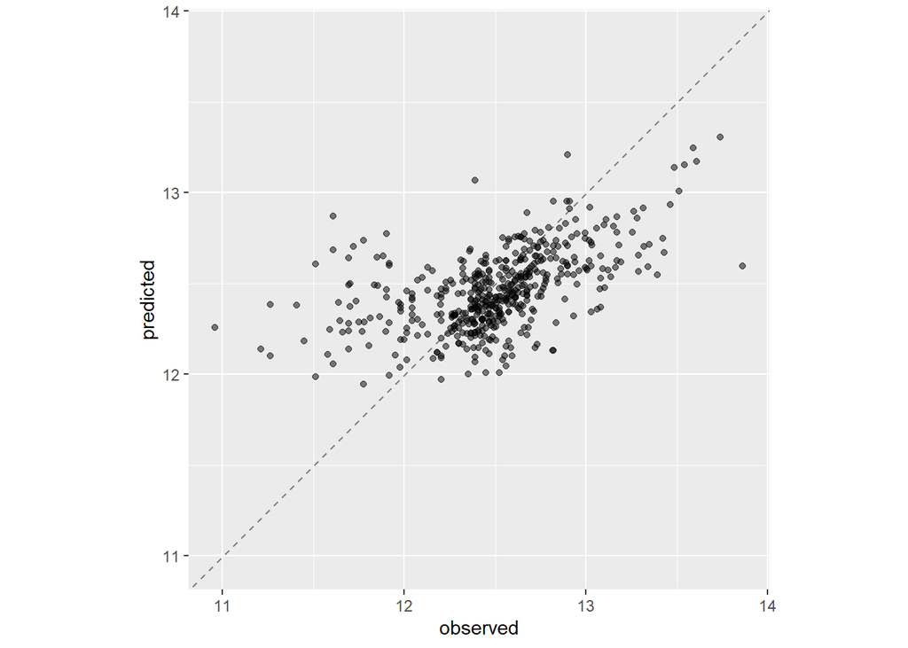

```r
best_results_fit %>%
   collect_predictions() %>%
   ggplot(aes(x = log_sale_price, y = .pred)) +
   geom_abline(color = "gray50", lty = 2) +
   geom_point(alpha = 0.5) +
   coord_obs_pred() +
   labs(x = "observed", y = "predicted")
```

### Bayes

```r
ctrl <- control_bayes(verbose = TRUE)

rf_workflow <-
  workflow() %>%
  add_model(rf_spec) %>%
  add_recipe(p3_sold_23_recipe)

rf_param <-
  rf_workflow %>%
  extract_parameter_set_dials() %>%
  update(
    mtry = mtry(c(2, 10)),  # Update the number of variables randomly sampled
    min_n = min_n(c(1, 10))  # Update the minimum number of observations in terminal nodes
    # Add/update more parameters as needed
  )

set.seed(1402)
rf_initial <-
  rf_workflow %>%
  tune_grid(resamples = folds_assess23, grid = 5, metrics = metric_set(rmse))

set.seed(1403)
# comment out for knitting
# rf_bo <-
#   rf_workflow %>%
#   tune_bayes(
#     resamples = folds_assess23,
#     metrics = metric_set(rmse),
#     initial = rf_initial,
#     param_info = rf_param,
#     iter = 25,
#     control = ctrl
#   )

#rf_bo %>% saveRDS('rf_bo.rds')

rf_bo <- readRDS('rf_bo.rds')

show_best(rf_bo)
```

```
## # A tibble: 5 × 9
##    mtry min_n .metric .estimator  mean     n std_err .config              .iter
##   <int> <int> <chr>   <chr>      <dbl> <int>   <dbl> <chr>                <int>
## 1    57    37 rmse    standard   0.346     5 0.00848 Preprocessor1_Model5     0
## 2    23    20 rmse    standard   0.347     5 0.00869 Preprocessor1_Model2     0
## 3    61    31 rmse    standard   0.347     5 0.00827 Preprocessor1_Model3     0
## 4    13     9 rmse    standard   0.349     5 0.00892 Preprocessor1_Model4     0
## 5    10    10 rmse    standard   0.350     5 0.00829 Iter7                    7
```

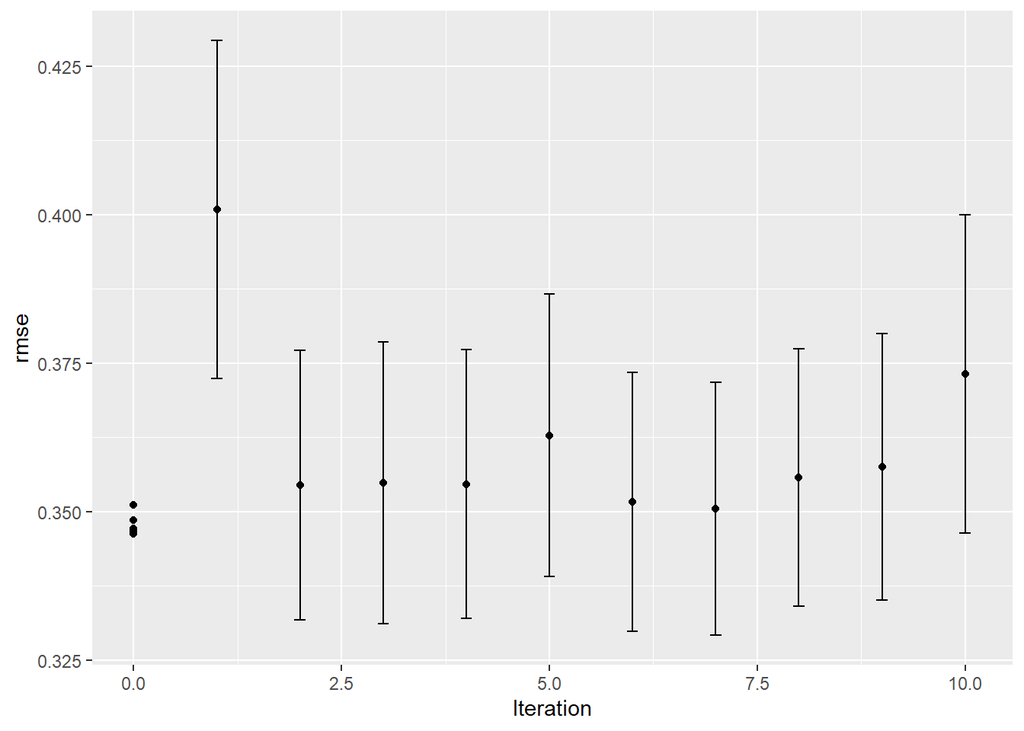

```r
autoplot(rf_bo, type = "performance")
```

```r
# Extract the best parameters found during tuning
best_params <- rf_bo %>%
  select_best(metric = "rmse")

# Fit the finalized model with the tuning results
final_wf <- finalize_workflow(rf_workflow, best_params)


final_wf
```

```
## ══ Workflow ════════════════════════════════════════════════════════════════════
## Preprocessor: Recipe
## Model: rand_forest()
##
## ── Preprocessor ────────────────────────────────────────────────────────────────
## 4 Recipe Steps
##
## • step_other()
## • step_novel()
## • step_unknown()
## • step_dummy()
##
## ── Model ───────────────────────────────────────────────────────────────────────
## Random Forest Model Specification (regression)
##
## Main Arguments:
##   mtry = 57
##   trees = 250
##   min_n = 37
##
## Computational engine: ranger
```

## Out of Sample Predictions

```r
# missing values create an error with augment
p3_oos <-
  part3_tb %>%
    drop_na(pin_is_multiland, pin_num_landlines, char_yrblt, char_bldg_sf,
            char_land_sf, char_beds, char_rooms, char_fbath, char_hbath,
            char_frpl, recent_renovation, nearest_golf_course_dist_ft)

final_model <-
  final_wf %>%
  fit(part3_sold_23)

oos_pred <- final_model %>% augment(p3_oos)
```

## Conclusions

### Comparisons

Overall our model predicts Proviso township sale price better than the assessor’s model. This is likely because the assessor’s model is trained on the entirety of Cook County, while our model is trained exclusively on Proviso township. The assessor’s model appears to undervalue the properties in Proviso. It is also possible that the assessments are out of date due to the triennial cycle.

#### By class

```r
oos_pred %>%
  group_by(class) %>%
  summarize(mailed_log_mean = mean(log(mailed_tot)),
            log_pred = mean(.pred),
            mean_log_sale = mean(log_sale_price, na.rm = T)) %>%
  mutate(mailed_log_mean = round(mailed_log_mean, 2),
         log_pred = round(log_pred, 2),
         mean_log_sale = round(mean_log_sale, 2)) %>%
  DT::datatable()
```

|  | class | mailed_log_mean | log_pred | mean_log_sale |
| --- | --- | --- | --- | --- |
| 1 | 202 | 9.74 | 12.26 | 12.25 |
| 2 | 203 | 9.92 | 12.44 | 12.46 |
| 3 | 204 | 10.17 | 12.73 | 12.73 |
| 4 | 205 | 10 | 12.54 | 12.52 |
| 5 | 206 | 10.52 | 12.97 | 13.07 |
| 6 | 207 | 9.91 | 12.63 | 12.63 |
| 7 | 208 | 11.22 | 13.24 | 14.15 |
| 8 | 209 | 11.24 | 13.21 | 13.61 |
| 9 | 234 | 10 | 12.59 | 12.63 |
| 10 | 278 | 10.59 | 13.01 | 13.16 |

#### Density Plot

Our predictions are much more narrow than the actual sales. This is somewhat expected since the model tends to predict towards the average, however the implications of this is that lower value properties are over-assessed while higher value properties are under-assessed.

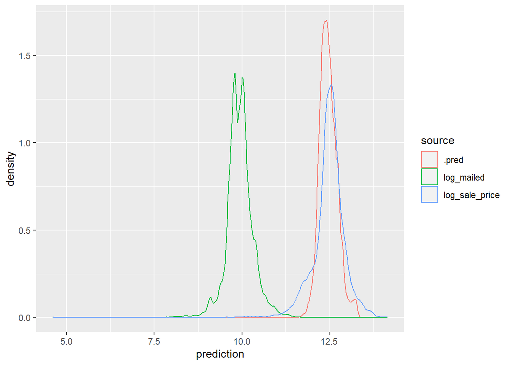

```r
# pivot long to add source as color variable
pred_tb <-
  oos_pred %>%
    group_by(pin) %>%
    mutate(log_mailed = log(mailed_tot),
           log_mailed_adj = log_mailed + 2.5) %>%
    select(c(log_mailed, .pred, log_sale_price, log_mailed_adj)) %>%
    pivot_longer(cols = !pin,
                 names_to = 'source',
                 values_to = 'prediction')

pred_tb %>%
  filter(source != 'log_mailed_adj') %>%
  ggplot() +
  geom_density(aes(prediction,
                   color = source))
```

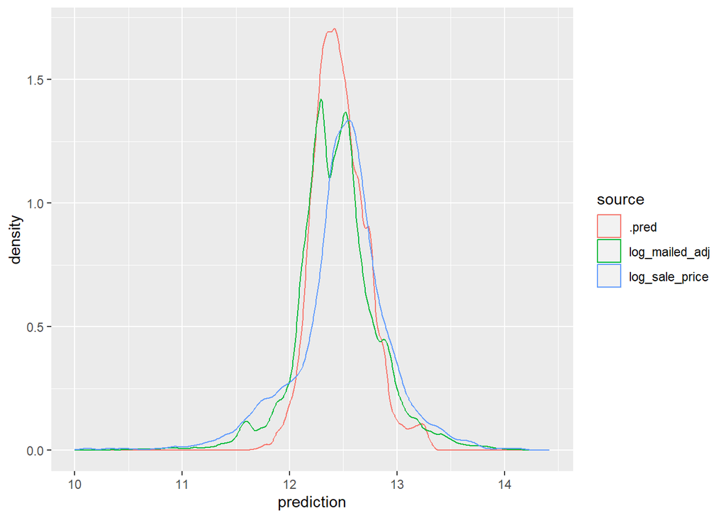

```r
pred_tb %>%
  filter(source != 'log_mailed') %>%
  ggplot() +
  geom_density(aes(prediction,
                   color = source)) +
  xlim(10, NA)
```

Ultimately, I do not recommend that the assessor utilize my model. While it appears to perform well, it is likely an out of date assessment. Adjusting the log_mailed variable by adding 2.5, we see that the assessor’s adjusted assessments are much closer to the distribution of sale_price.